# beatochess no. 17 (October 2026)

Beat Neuenschwander, neuenschwander.beat@gmail.com, https://github.com/beatochess/

# 1 Moriz Henneberger (1878-1959)

I recently stumbled over a minimalist but charming study by the Swiss composer Moriz Henneberger (see below). I then looked at Henneberger’s studies in more detail. Among others, Mario Garcia has cooked and corrected some of Henneberger’s studies.

A major part of Henneberger’s studies shows the rook-desperado theme. Checking these studies is somewhat tricky because often there are various ways to win. In most cases, however, the winning idea remains the same; that is, the alternative winning moves are minor duals.

Below is a summary of findings.

## 1.1 Two knights vs. rook and knight (GBR 0305.00)

**HHdbVI** has 34 studies with the GBR material 0305.00 in the starting position. The first two studies were composed by Henri Rinck in National-Zeitung (Basel, Switerland) in 1923. Both turned out to be incorrect. Moriz Henneberger was certainly inspired by Rinck’s studies. His study has a surprising first move. As often the case with Hennebergers studies, it is rather sketchy in that it has no introduction.

My study has a three-move introduction. However, endgame tablebases are needed to understand why White’s way to draw is unique. The study shows the richness of chess endgames…

Here are the two technical terms used in the **Syzygy endgame tablebase;** the link is [syzygy](http://syzygy-tables.info)

- **DTZ** (distance to zeroing): the number of half-moves (ply) until a pawn move or a capture.
- **DTM** (distance to mate): the number of half-moves (ply) to mate

The number of moves required to refute the White tries is mind-boggling!

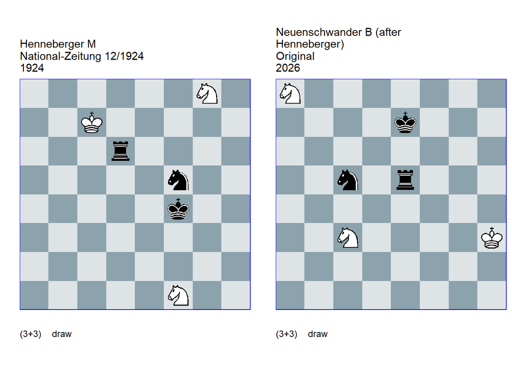

GBR: =0305.00c7f4 FEN: 6N1/2K5/3r4/5n2/5k2/8/8/5N2 w - - 0 1

source: National-Zeitung 12/1924 **1. Ne3!** (1. Ne7? Rd3! 2. Ng6+ Ke4!) **1… Kxe3 2. Ne7! Rf6** (2… Nxe7 3. Kxd6) **3. Nd5+ Kd4 4. Nxf6 1/2-1/2**.

GBR: =0305.00h3e7 FEN: N7/4k3/8/2n1r3/8/2N4K/8/8 w - - 0 1

**1. Kg4!** (1. Nb6? DTZ 133 DTM 175 1… Rg5!) (1. Nc7? DTZ 123 DTM 162 1… Rg5) (1. Nb5) **1… Nd7 2. Kf4!** (2. Nc7? DTZ 229 DTM 269 2… Kd6!) **2… Kd6** (2… Rc5 3. Nc7!) **3. Ne4+ Kc6** (3… Kd5 4. Nc7+) **4. Nb6!! Kxb6 5. Nf6 Re7 6. Nd5+ 1/2-1/2**.

## 1.2 Comments and revisions

### 1.2.1 Henneberger +0301.32a1a7 (1908). Correction

Dropping the black pawn on a5 makes the study correct and makes the study more interesting due to the try 1. Nf7.

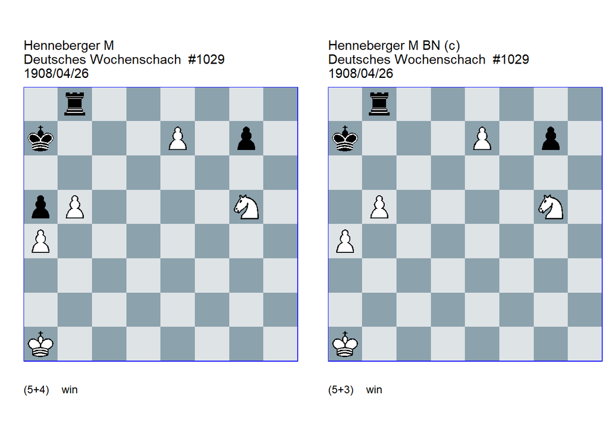

GBR: +0301.32a1a7 U3 FEN: 1r6/k3P1p1/8/pP4N1/P7/8/8/K7 w - - 0 1

source: Deutsches Wochenschach#1029 no.17 26-4-1908; U3: Garcia=M HHdbV 24-9-2011 **1. Ne4 g5** (1… Re8 2. Nd6) (1… Kb6 2. Nd6) (1… Rg8 2. Kb2 g5 3. Kc3 g4 4. Kd4 Kb6 5. Kd5 Kc7 6. Ke6 Rh8 7. Kf7 Kd7 (7… Rh7+ 8. Kf8 Rh8+ 9. Kg7 Re8 10. Kf7) 8. Nf6+) **2. Nf6 g4** (2… Kb7 3. e8=Q Rxe8 4. Nxe8 g4 5. Nd6+) (2… Rh8 3. Kb2 Rc8 4. Kb3 Rh8 5. Kc3) **3. Nxg4 Re8 4. Ne5 Kb6 5. Nc6 Kc5!** **cook** MG **1-0**.

GBR: +0301.31a1a7 C FEN: 1r6/k3P1p1/8/1P4N1/P7/8/8/K7 w - - 0 1

source: Deutsches Wochenschach#1029 no.17 26-4-1908; correction: Neuenschwander=B beatochess no. 17 10/2026 (web) **1. Ne4** (1. Nf7? Rg8 2. a5 g5 3. b6+ Ka6 4. Nd8 g4 5. b7 Ka7 6. a6 g3 7. Nc6+ Kb6 8. b8=Q+ Rxb8 9. Nxb8 g2 10. e8=Q g1=Q+ 11. Kb2 Qf2+ =) **1… g5 2. Nf6** (2. Nxg5? Re8 =) **2… g4 3. Nxg4 Re8 4. Ne5 Kb6 5. Nc6 Kc5 6. Kb2** ( or 6. Kb1) (6. Ka2? Rh8 7. Kb3 Rh3+ 8. Kc2 Re3 9. Kd2 Re6 =) **1-0**.

### 1.2.2 Henneberger +0800.11h7a1 (1919). Additional cook

There is also the cook **1. Ra5+!**, which leads to a winning rook ending.

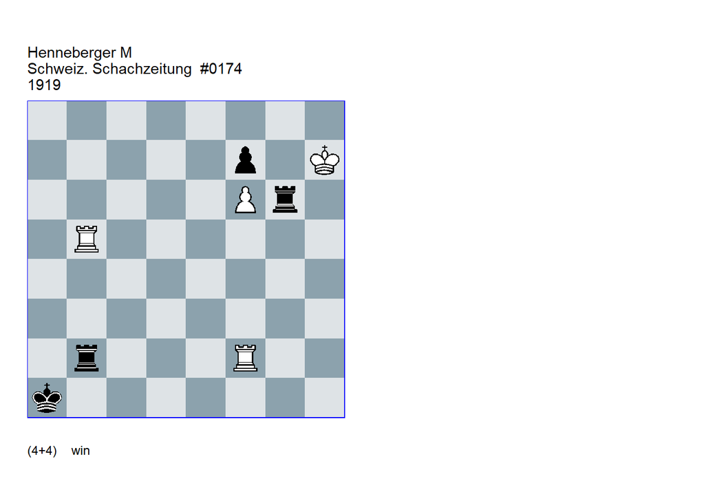

GBR: +0800.11h7a1 U2 U1 FEN: 8/5p1K/5Pr1/1R6/8/8/1r3R2/k7 w - - 0 1

source: Schweiz. Schachzeitung#0174 no.12 12/1919; U2: Haworth=G Bleicher=E HHdbV 9-12-2009; U1: Neuenschwander=B beatochess no.17 10/2026 (web). **1. Rfxb2** (1. Ra5+! **cook** **BN** 1… Kb1 2. Rf1+ Kc2 3. Ra7) **1… Rh6+ 2. Kg8 Rg6+ 3. Kf8 Rg8+ 4. Ke7 Re8+ 5. Kd6 Re6+ 6. Kc5 Re5+** (6… Rc6+ 7. Kd5 Rd6+ 8. Ke5 Re6+ 9. Kf5) **7. Kb4 Re4+ 8. Ka5 Ra4+ 9. Kb6 Ra6+ 10. Kc5 Rc6+ 11. Kd5 Rd6+ 12. Ke5 Re6+ 13. Kf5 Rxf6+ 14. Kg5** (14. Ke4! **cook** GH/EB ) (14. Ke5! **cook** GH/EB ) (14. Kg4! **cook** GH/EB ) **14… Rg6+ 15. Kh5 1-0**.

### 1.2.3 Henneberger +0800.11b5a1 (1919). Cook

**7. Ke7!** cooks the study.

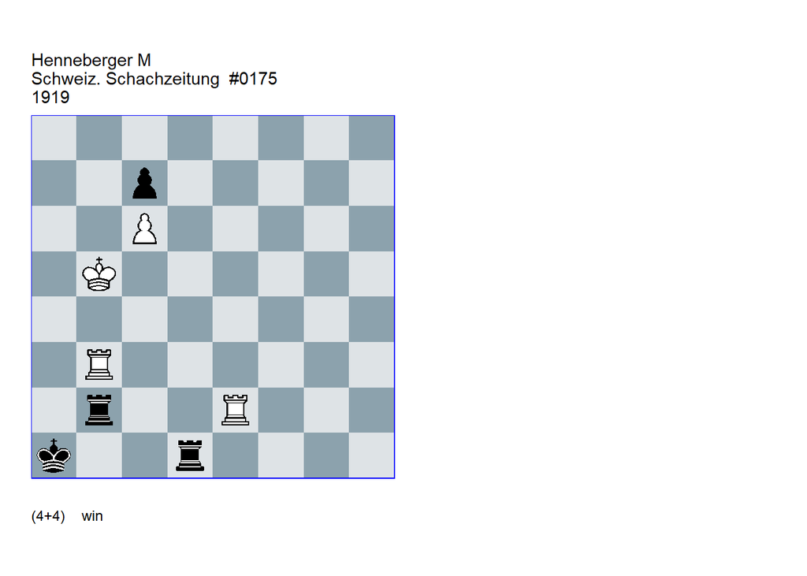

GBR: +0800.11b5a1 U2 FEN: 8/2p5/2P5/1K6/8/1R6/1r2R3/k2r4 w - - 0 1

source: Schweiz. Schachzeitung#0175 no.12 12/1919; U2: Neuenschwander=B beatochess no.17 10/2026 (web). **1. Rbxb2 Rd5+ 2. Ka6 Ra5+ 3. Kb7 Rb5+ 4. Kc8 Rb8+ 5. Kd7 Rd8+ 6. Ke6 Rd6+ 7. Kf5** (7. Ke7! **cook** **BN** ) **7… Rf6+ 8. Ke4 Rf4+** (8… Re6+ 9. Kd3 Rd6+ 10. Kc2) **9. Ke5 Rf5+ 10. Ke6 Rf6+ 11. Ke7 Rf7+ 12. Kd8 Rf8+ 13. Re8 1-0**.

### 1.2.4 Henneberger +0800.22g5a1 (1920). Cook

**1. Rdxb2!** cooks the author’s correction.

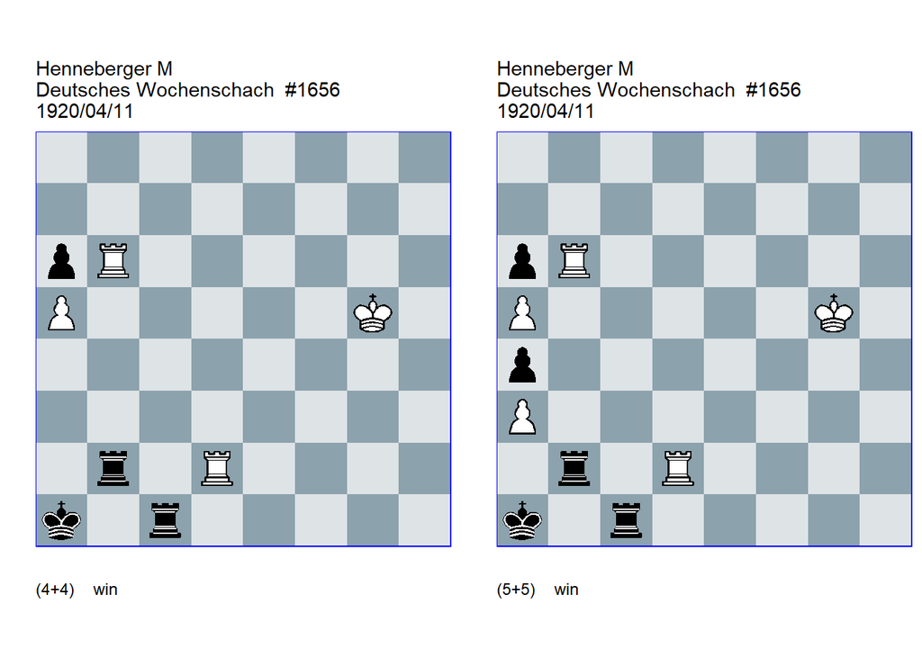

GBR: +0800.11g5a1 U2 FEN: 8/8/pR6/P5K1/8/8/1r1R4/k1r5 w - - 0 1

source: Deutsches Wochenschach#1656 no.14-15 11-4-1920; U2: Deutsches Wochenschach=27-28 11-7-1920 **1. Rbxb2 Rc5+ 2. Kh4!** (2. Kg4? Rg5+ 3. Kf3 Rf5+ 4. Ke2 Re5+ 5. Kd3 Rd5+! (5… Re3+? 6. Kd4) 6. Kc3 (6. Kc2 Rxd2+) 6… Rc5+ 7. Kb3 Rb5+ 8. Ka3 Rb3+ 9. Ka4 Rb4+) (2. Kf6? Rc6+ 3. Ke7 Re6+ ( 3… Rc7+? 4. Rd7) 4. Kd8 Re8+ 5. Kc7 Rc8+ 6. Kb6 Rb8+ (6… Rc6+? 7. Ka7) 7. Ka7 (7. Kc6 Rc8+) 7… Rb7+ 8. Ka8 Rb8+) (2. Kf4! **cook** Rf5+ 3. Ke3 Re5+ 4. Kd3 Rd5+ 5. Ke2 Re5+ 6. Kd1 Re1+ 7. Kc2 Rc1+ 8. Kd3 Rc3+ 9. Ke4 Re3+ 10. Kd5 Re5+ 11. Kc6 Rc5+ 12. Kb6 Rc6+ 13. Ka7) **2… Rh5+ 3. Kg3 Rg5+ 4. Kf2 Rf5+ 5. Ke1 Rf1+ 6. Ke2 Re1+ 7. Kd3 Re3+ 8. Kd4 Re4+ 9. Kd5** (9. Kc5? Rc4+ 10. Kb6 Rb4+!) **9… Re5+ 10. Kc6 Rc5+** (10… Re6+ 11. Rd6) **11. Kb6 Rc6+ 12. Ka7 Rc7+ 13. Rb7 1-0**.

GBR: +0800.22g5a1 C U1 FEN: 8/8/pR6/P5K1/p7/P7/1r1R4/k1r5 w - - 0 1

source: Deutsches Wochenschach#1656 no.14-15 11-4-1920; (c): Henneberger=M (Deutsches Wochenschach no.27-28 11-7-1920); U1: Neuenschwander=B beatochess no.17 10/2026 (web). **1. Rbxb2** (1. Rdxb2! **cook** **BN** 1… Rc5+ 2. Kf6 Rf5+ 3. Ke6 Re5+ 4. Kd6 Rd5+ 5. Kc6 Rc5+ 6. Kb7 Rc7+ 7. Kxa6 Ra7+ 8. Kb5 Rxa5+ 9. Kb4) **1… Rc5+ 2. Kh4!** (2. Kg4? Rg5+ 3. Kf3 Rf5+ 4. Ke2 Re5+ 5. Kd3 Rd5+! 6. Kc3 (6. Kc2 Rxd2+) 6… Rc5+ 7. Kb4 Rb5+ 8. Kxa4 Rb4+ 9. Kxb4) (2. Kf6? Rc6+ 3. Ke7 Re6+ 4. Kd8 Re8+ 5. Kc7 Rc8+ 6. Kb6 Rb8+ 7. Ka7 Rb7+ 8. Ka8 Rb8+) (2. Kf4? Rf5+ 3. Ke3 Re5+ 4. Kd3 Rd5+ 5. Ke2 Re5+ 6. Kd1 Re1+ 7. Kc2 Rc1+ 8. Kd3 Rc3+ 9. Ke4 Rc4+) **2… Rh5+ 3. Kg3 Rh3+ 4. Kf2 Rf3+ 5. Ke1 Rf1+ 6. Ke2 Re1+ 7. Kd3 Re3+ 8. Kd4! Re4+ 9. Kd5** (9. Kc5 or ) **9… Re5+ 10. Kc6 Rc5+** ( 10… Re6+ 11. Rd6) **11. Kb6 Rc6+ 12. Ka7 Rc7+ 13. Rb7 1-0**.

### 1.2.5 Henneberger =0305.00e6e8 (1924). Cook?

There is a cook in the second mainline. This could be demoted to a sideline if the stalemate is the study’s main idea, which would make the study correct.

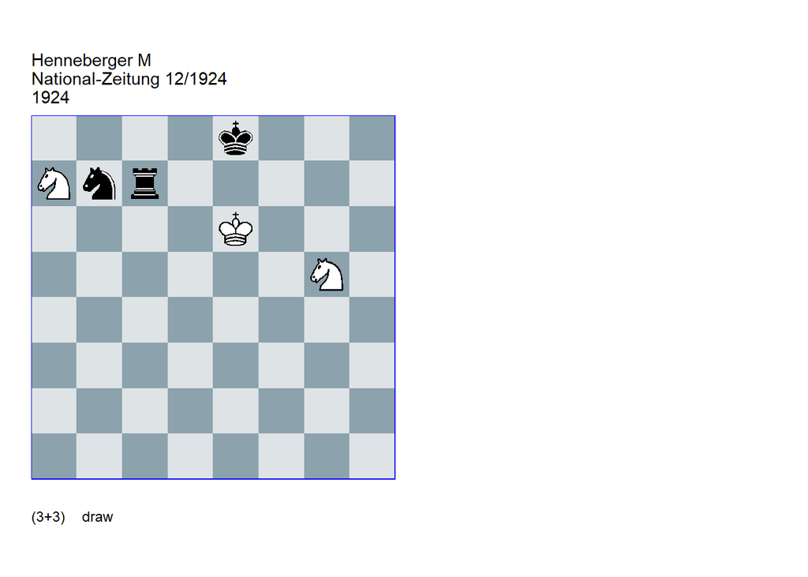

GBR: =0305.00e6e8 U2 FEN: 4k3/Nnr5/4K3/6N1/8/8/8/8 w - - 0 1

source: National-Zeitung 12/1924; Neuenschwander=B beatochess no.17 10/2026 (web) **1. Kf6!** (1. Nb5? Rc6+! (1… Nd8+? 2. Kf6) ) **1… Nd6** (1… Nd8 main 2. Nb5 Rc6+ 3. Kg7! Rc5 4. Ne4 (4. Nd6+! **cook** **BN** ) 4… Rxb5 5. Nd6+ Kd7 6. Nxb5) **2. Ke6!** (2. Ke5? Nc4+ 3. Kd4 Na3) **2… Nc4! 3. Nb5** ( 3. Kd5? Nb6+ 4. Kd6 Rxa7) **3… Rc5! 4. Nd6+! Nxd6 5. Ne4! Nxe4 1/2-1/2**.

### 1.2.6 Henneberger =0311.01a3b6 (1925). Cook

**1. Bd7!** cooks the study.

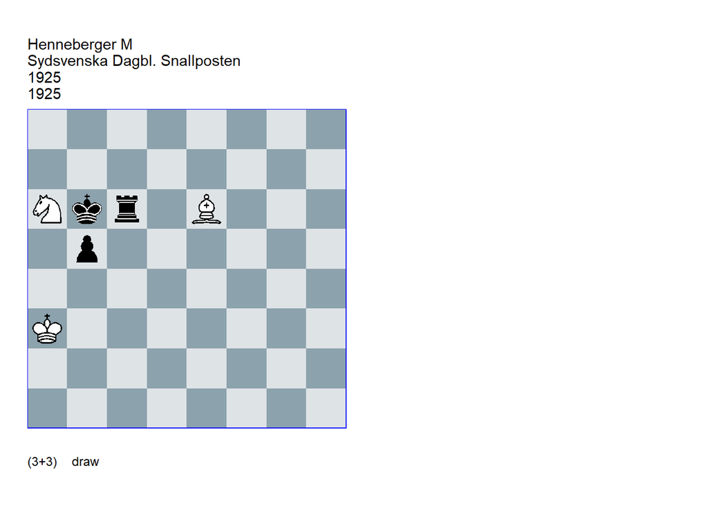

GBR: =0311.01a3b6 U1 FEN: 8/8/Nkr1B3/1p6/8/K7/8/8 w - - 0 1

source: Sydsvenska Dagbl. Snallposten 1925; U2: Neuenschwander=B beatochess no.17 10/2026 (web) **1. Bd5!** (1. Bd7! **cook** **BN** 1… Rc3+ (1… Rd6 2. Bxb5 Kxb5 3. Nb4) 2. Kb2 Rd3 3. Nb8) **1… Rc3+ 2. Kb2! Rd3 3. Nb4 Rd4 4. Kc3 Kc5 5. Na6+ Kxd5 6. Nc7+ Ke5** (6… Kc5 7. Ne6+) **7. Nxb5 1/2-1/2**.

Compared to the author’s study, the version has two introductory moves and the same material.

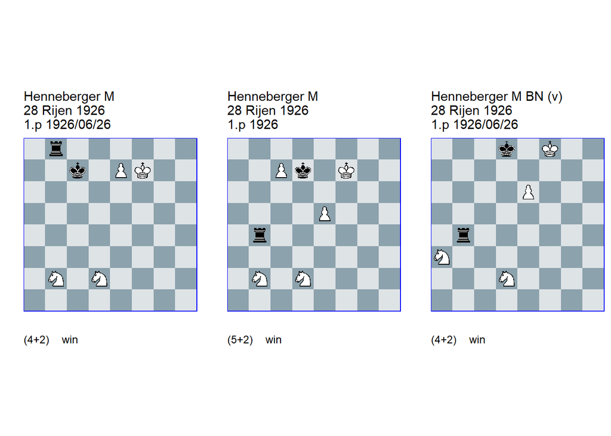

GBR: +0302.10f7c7 FEN: 1r6/2k1PK2/8/8/8/8/1N1N4/8 w - - 0 1

source: 28 Rijen#290 26-6-1926 **1. Ne4! Kc6** (1… Rh8 2. Nf6) (1… Kb6 2. Nc4+ Ka7 3. Ncd6 Rh8 4. Nf6) **2. Nc4 Kd5 3. Nf6+! Kxc4** (3… Kc6 main 4. Ne5+! Kb5 (4… Kd6 main 5. Ned7 Ra8 6. Nf8 Ra7 7. N6d7 Ra8 8. Nb6 Rb8 9. Nfd7 Rh8 10. Nf8) 5. Ned7 Ra8 6. Nd5 Kc6 7. N5b6) **4. Nd7 Rc8** (4… Rh8 5. Nf8) (4… Ra8 5. Nb6+) **5. Nb6+ Kc5 6. Nxc8 1-0**.

GBR: +0302.20f7d7 M FEN: 8/2Pk1K2/8/4P3/1r6/8/1N1N4/8 w - - 0 1

source: 28 Rijen#290 1926; (m): Samilo=V (Idee und Form no.146 4/2020) **1. e6+!** (1. Nd3? Rh4!) **1… Kxc7 2. e7!** (2. Nbc4? Rb7! 3. e7 Kb8! (3… Kc6? 4. Na5+) (3… Kc8? 4. Nd6+!) ) **2… Rb8** (2… Rf4+ 3. Ke6!) **3. Ne4! Kc6** (3… Rh8 4. Nf6) **4. Nc4** (4. Nd3? Rb7 5. Ne5+ Kb6! (5… Kd5? 6. Nd7! Rxd7 7. Nf6+ Kd6 8. Nxd7) ) **4… Kd5 5. Nf6+!** (5. Ned6? Rh8!) **5… Kxc4 6. Nd7 Rc8** (6… Rh8 7. Nf8) **7. Nb6+ Kb5 8. Nxc8 1-0**.

GBR: +0302.10f7c7 V FEN: 3k1K2/8/4P3/8/1r6/N7/3N4/8 w - - 0 1

source: 28 Rijen#290 26-6-1926; version: Neuenschwander=B beatochess no.17 10/2026 (web). **1. e7+ Kc7 2. Kf7 Rb8 3. Ne4 Kc6 4. Nc4 Kd5 5. Nf6+ Kxc4 6. Nd7 1-0**.

### 1.2.8 Henneberger +1340.02h7a1 (1933). Cook

**1. Kh6!** cooks the study.

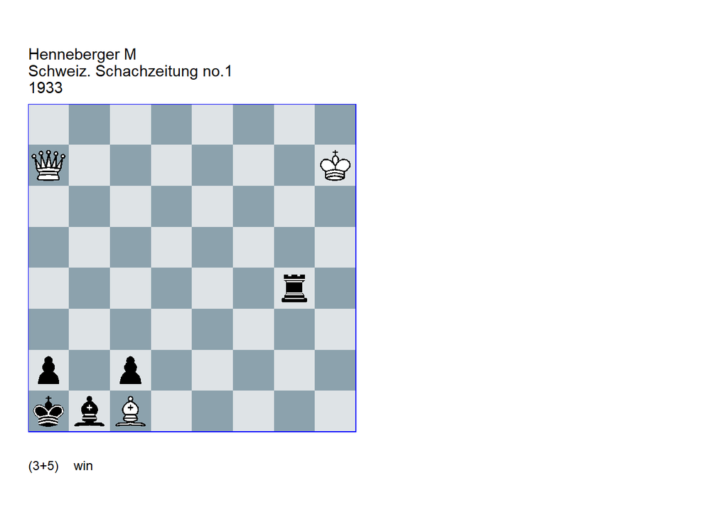

GBR: +1340.02h7a1 U1 FEN: 8/Q6K/8/8/6r1/8/p1p5/kbB5 w - - 0 1

source: Schweiz. Schachzeitung no.1 1/1933; U1: Neuenschwander=B beatochess no.17 10/2026 (web). **1. Qc7** (1. Qb7? Rh4+ 2. Kg6 Rh6+ 3. Kf5 Rh5+ 4. Ke6 Re5+! 5. Kf6 Rf5+ 6. Kg6 Rg5+ 7. Kh7 Rh5+ 8. Kg7 Rh7+) (1. Qb8! Rg7+ 2. Kh6 Rh7+ 3. Kg6 Rg7+ 4. Kf6 Rf7+ 5. Ke6 Re7+ 6. Kd6 Rd7+ 7. Kc6 Rc7+ 8. Kb6 Rb7+) (1. Kh6! **cook** **BN** ) **1… Rh4+ 2. Kg6 Rh6+** (2… Rg4+ 3. Kf6 Rg6+ 4. Kf5 Rg5+ (4… Rf6+ 5. Kg4) 5. Ke6 Rg6+ 6. Kd5 Rd6+ 7. Ke4 Re6+ (7… Rd4+ 8. Kf3) 8. Kf3) **3. Kf5 Rf6+** (3… Rh5+ 4. Ke6) **4. Kg4 Rg6+ 5. Kh5 1-0**.

### 1.2.9 Henneberger +1340.12c6a1 (1933). Cook

**6. Qxa2+!** cooks the study.

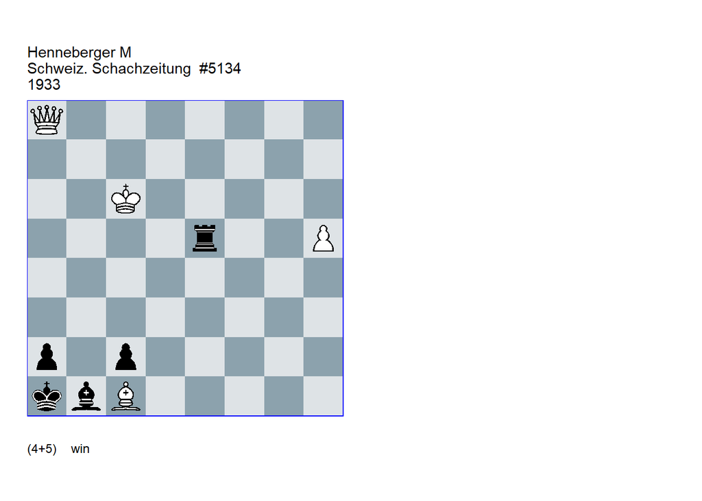

GBR: +1340.12c6a1 U2 FEN: Q7/8/2K5/4r2P/8/8/p1p5/kbB5 w - - 0 1

source: Schweiz. Schachzeitung#5134 no.1 1/1933; U2: Neuenschwander=B beatochess no.17 10/2026 (web). **1. h6! Rc5+ 2. Kd6 Rd5+ 3. Ke6 Re5+ 4. Kf7 Rf5+ 5. Kg7 Rf8! 6. Qa3** (6. Qxa2+! **cook** **BN** ) **6… Rg8+ 7. Kf6 Rg6+ 8. Ke5 Re6+ 9. Kf5 Re5+** (9… Rf6+ 10. Kg4 Rg6+ 11. Kh5) **10. Kg4 Re4+ 11. Kf3 1-0**.

### 1.2.10 Henneberger =3101.00d1a1 (1941). Cook, correction

**2… Ka3!** cooks the study.

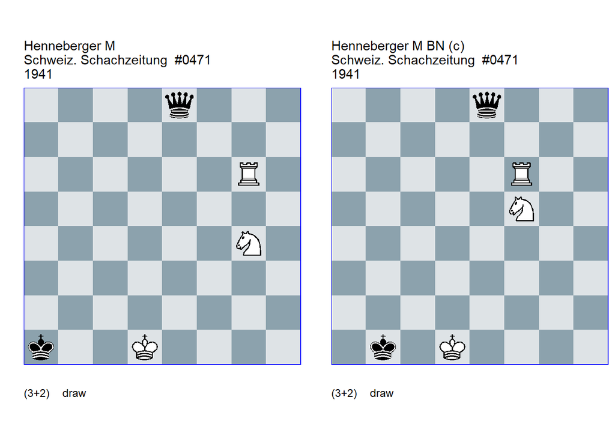

GBR: =3101.00d1a1 U3 FEN: 4q3/8/6R1/8/6N1/8/8/k2K4 w - - 0 1

source: Schweiz. Schachzeitung#0471 no.11 11/1941; U3: Neuenschwander=B beatochess no.17 10/2026 (web). **1. Ra6+ Kb2 2. Rb6+ Kc3** (2… Ka3! **cook** **BN** ) **3. Ne3! Qxe3** (3… Qd8+ 4. Ke2 Qd3+ 5. Kf3) **4. Rb3+ Kxb3 1/2-1/2**.

GBR: =3101.00d1b1 C FEN: 4q3/8/5R2/5N2/8/8/8/1k1K4 w - - 0 1

source: Schweiz. Schachzeitung#0471 no.11 11/1941; correction: Neuenschwander=B beatochess no.17 10/2026 (web). **1. Rb6+** (1. Nd4? Qa4+) **1… Ka2 2. Ra6+ Kb2 3. Rb6+ Kc3** (3… Ka3 4. Nd6!) **4. Ne3! Qxe3** (4… Qd8+ 5. Ke2 Qxb6 6. Nd5+) **5. Rb3+ Kxb3 1/2-1/2**.

### 1.2.11 Henneberger +1400.42g2h4 (1944). Cook

**1. Qe3!** cooks the study.

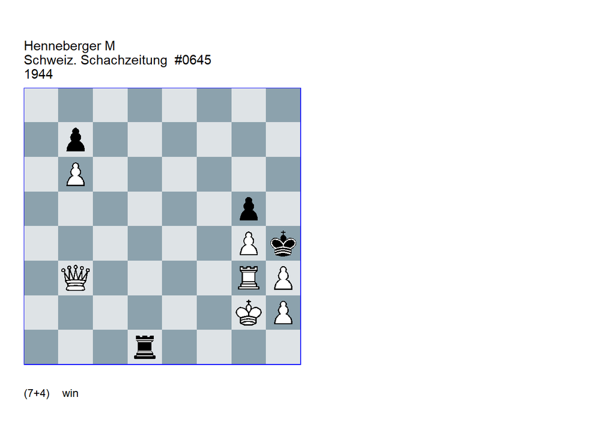

GBR: +1400.42g2h4 U1 FEN: 8/1p6/1P6/6p1/6Pk/1Q4RP/6KP/3r4 w - - 0 1

source: Schweiz. Schachzeitung#0645 no.6 6/1944; U1: Neuenschwander=B beatochess no.17 10/2026 (web). **1. Qg8!** (1. Qe3! **cook** **BN** 1… Rg1+ 2. Kf3 Rf1+ 3. Ke4) **1… Rg1+** (1… Rd2+ 2. Kh1 Rxh2+ (2… Rd1+ 3. Rg1) 3. Kg1) **2. Kf3 Rf1+ 3. Ke4 Rf4+ 4. Ke5 Re4+ 5. Kd6 Rd4+ 6. Kc7 Rc4+ 7. Kb8 Rc8+ 8. Ka7 Ra8+** (8… Rxg8 9. Rg2 Kxh3 10. Rc2 Kxg4 11. Kxb7) **9. Kxb7 Ra7+** (9… Rb8+ 10. Kc6 Rc8+ 11. Kd5 Rd8+ 12. Ke4 Re8+ 13. Kf3 Rf8+ (13… Rxg8 14. Rg1) 14. Kg2 Rxg8 15. Rb3!) **10. Kc6 Rc7+ 11. Kd5 Rc5+ 12. Ke4 Rc4+ 13. Kf3 Rc3+ 14. Kg2 Rc2+ 15. Kh1 1-0**.

# 2 Comments and revisions

## 2.1 Prize winners

### 2.1.1 Bondarev +4031.03h6d8 (1968). De-cooked (VH)

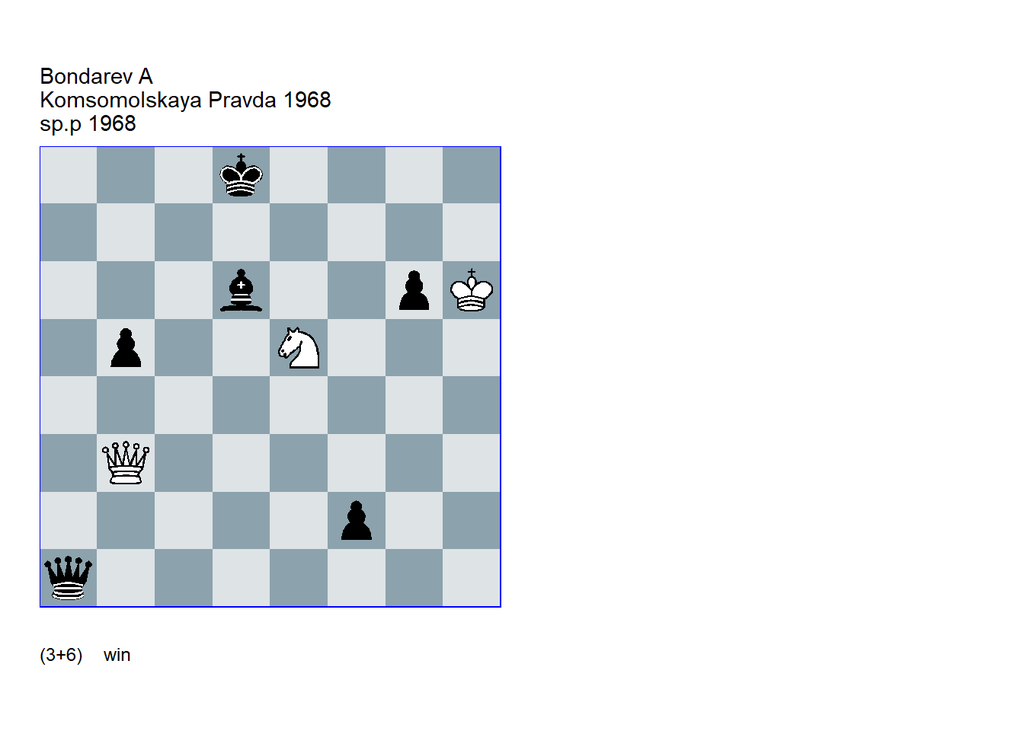

GBR: +4031.03h6d8 FEN: 3k4/8/3b2pK/1p2N3/8/1Q6/5p2/q7 w - - 0 1

### 2.1.2 Badai +0440.12f3e7 (1963). Version

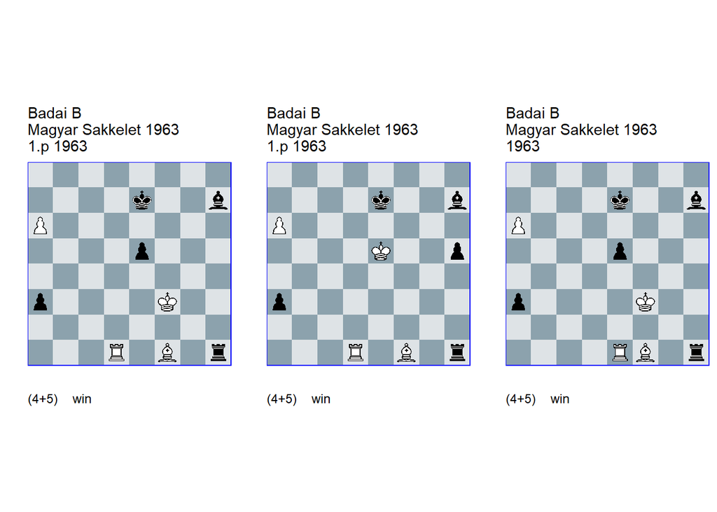

GBR: +0440.12f3e7 TW V U2 FEN: 8/4k2b/P7/4p3/8/p4K2/8/3R1B1r w - - 0 1

(EG#00099); source: Magyar Sakkelet#0514a 1963; (v): Badai=B Magyar Sakkelet 1963 (Magyar Sakkelet#0534a 1963 2/1964); U2: Garcia=M EG=173 7/2008 **1. a7 Be4+ 2. Kxe4 Rh4+ 3. Kf5!** (3. Ke3! **cook** MG ) **3… Rf4+ 4. Kg5! Ra4 5. Ba6! Rxa6 6. Rh1 Kd7 7. Rh8 a2 8. a8=Q a1=Q** eg **9. Qd5+ 1-0**.

GBR: +0440.12e5e7 TW V U2 FEN: 8/4k2b/P7/4K2p/8/p7/8/3R1B1r w - - 0 1

source: Magyar Sakkelet#0514b 8 /1963; (v): Badai=B Magyar Sakkelet 1963 (Magyar Sakkelet#0534b 1963 2/1964); U2: Garcia=M HHdbV 22-9-2011 U2: Afek=Y HHdbVI 6-8-2020 **1. a7 Be4! 2. Kxe4** (2. Rd5! **cook** MG ) **2… Rh4+ 3. Kf5! Ra4 4. Re1+ Kf7! 5. Bc4+ Kf8 6. Re8+** (6. Rg1! **cook** YA 6… Rxa7 7. Rg8+ Ke7 8. Rg7+) **6… Kxe8 7. Bb5+ Ke7! 8. Bxa4 a2 9. a8=Q a1=Q 10. Qe8+! Kd6 11. Qd7+ Kc5 12. Qc6+ Kb4 13. Qb5+ Kc3 14. Qe5+ 1-0**.

GBR: +0440.12f3e7 U2 FEN: 8/4k2b/P7/4p3/8/p4K2/8/4RB1r w - - 0 1

source: Magyar Sakkelet#0514 8/1963; U2: Fleck=J HHdbII 20-1-1998 U2: Garcia=M HHdbV 22-9-2011 **1. a7 Be4+! 2. Kxe4 Rh4+ 3. Kf5!** (3. Kxe5! **cook** JF 3… Ra4 4. Kf5+ Kd8 5. Re8+ Kxe8 6. Bb5+ Ke7 7. Bxa4 a2 8. a8=Q a1=Q 9. Qe8+ Kd6 10. Qd7+ Kc5 11. Qc6+ Kb4 12. Qb5+ Kc3 13. Qe5+) (3. Ke3! **cook** MG 3… Ra4 4. Ba6 Rxa6 5. Rh1) **3… Rf4+! 4. Kg5** (4. Kxe5? Ra4) **4… Ra4 5. Ba6! Rxa6 6. Rh1! Kd7** (6… Kd6 7. Rh6+) (6… Rxa7 7. Rh7+) **7. Rh8 a2** ( 7… Rxa7 8. Rh7+) **8. a8=Q a1=Q 9. Qd5+ 1-0**.

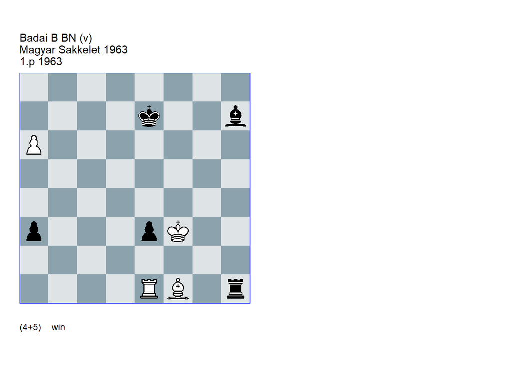

GBR: +0440.12f3e7 V FEN: 8/4k2b/P7/8/8/p3pK2/8/4RB1r w - - 0 1

(EG#00099); source: Magyar Sakkelet#0514a 1963; (v): Neuenschwander=B beatochess no.17 10/2026 (web). **1. a7** (1. Rxe3+? Kd6!) **1… Be4+ 2. Kxe4 Rh4+ 3. Kxe3!** (3. Kf5? Rh5+! (3… Ra4? 4. Rxe3+ Kd8 (4… Kf7 5. Bc4+ Kg7 6. Rg3+ Kh7 7. Kf6 +/-) ( or 4… Kf8 5. Re8+) 5. Re8+! Kxe8 6. Bb5+ Ke7 7. Bxa4 a2 8. a8=Q +-) 4. Kf4 Ra5 =) (3. Kd5? Ra4 4. Rxe3+ Kf7! ( 4… Kf8? 5. Re8+!) (4… Kf6? 5. Re6+) ) **3… Ra4 4. Ba6! Rxa6 5. Rh1 Kd7 6. Rh8** (6. Rh6 Ra5 7. Rh5 etc. loses time ) **6… Rxa7 7. Rh7+ 1-0**.

### 2.1.3 Boros +4040.03e7h8 (1936). Correction (VH)

Volker Hergert corrected the study.

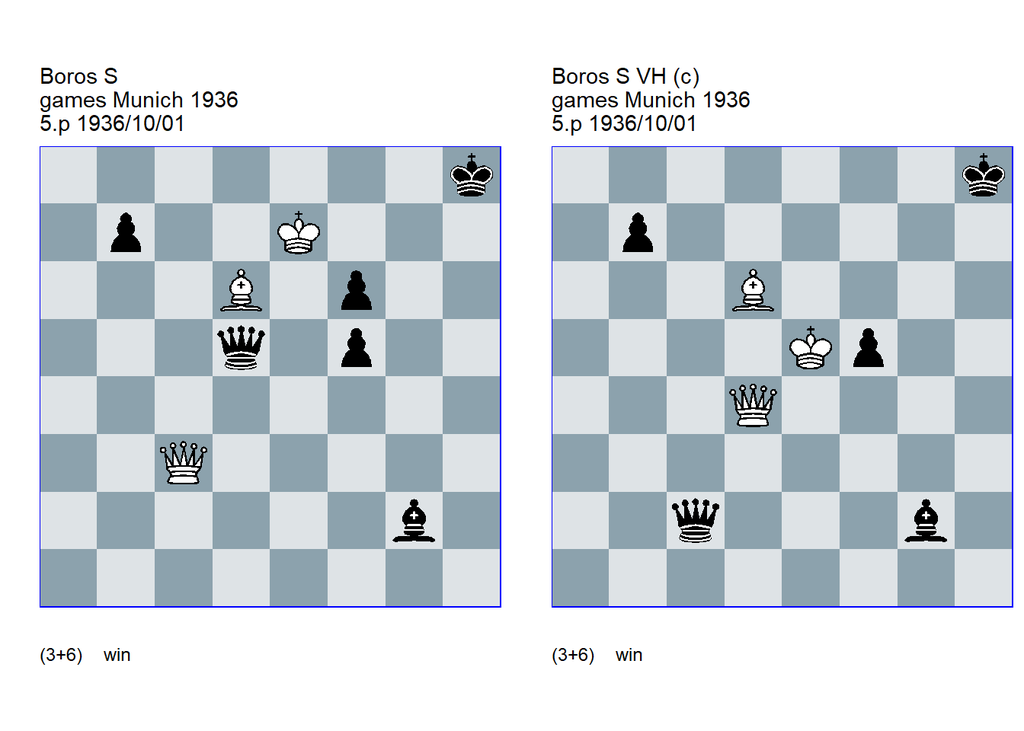

GBR: +4040.03e7h8 U3 FEN: 7k/1p2K3/3B1p2/3q1p2/8/2Q5/6b1/8 w - - 0 1

source: Deutsche Schachblatter#21 no.19 1-10-1936; U3: Garcia=M HHdbIV 20-7-2006 **1. Kxf6 Qc6!** (1… Qg8 2. Bf8! Qxf8+ (2… Qh7 3. Qg3!) (2… Kh7 3. Qc7+) (2… Qg4! **cook** MG ) 3. Kg6+ Kg8 4. Qc4+ Kh8 5. Qh4+ Kg8 6. Qh7#) **2. Qe5 Qe4** (2… Qd7 3. Be7! Qe8 4. Qh2+) **3. Qh2+ Kg8 4. Qg3+ Qg4 5. Qb3+ Kh8** (5… Kh7 6. Qf7+ Kh8 (6… Kh6 7. Bf4+ Qxf4 8. Qg6#) 7. Be5!) **6. Be5! Qg8! 7. Qd1!** (7. Qd3 Qg4) **7… Qg4** (7… Qe8 8. Qc2! Qg8 (8… Qd7 9. Qxg2) 9. Qxf5 Qe8! 10. Qg5 Qf8+ (10… Qd7 11. Qg6) 11. Kg6+ Kg8 12. Kh5+ Kf7 13. Qg6+ Ke7 14. Bd6+) **8. Qd8+ Kh7** (8… Qg8 9. Kxf5+ Kh7 10. Qh4#) **9. Qc7+ Kh8 10. Qf7 Qh4+** eg **11. Ke6+ 1-0**.

GBR: +4040.03e7h8 C FEN: 7k/1p6/3B4/4Kp2/3Q4/8/2q3b1/8 w - - 7 1

source: Deutsche Schachblatter#21 no.19 1-10-1936; correction: Hergert=V beatochess no.17 10/2026 (web). **1. Kf6! Qe4 2. Qc3! Qc6 3. Qe5 Qe4 4. Qh2+ Kg8 5. Qg3+ Qg4 6. Qb3+ Kh8** (6… Kh7 7. Qf7+ Kh8 (7… Kh6 8. Bf4+ Qxf4 9. Qg6#) 8. Be5!) **7. Be5! Qg8! 8. Qd1! Qg4** (8… Qe8 9. Qc2! Qg8 (9… Qd7 10. Qxg2) 10. Qxf5 Qe8! 11. Qg5 Qf8+ (11… Qd7 12. Qg6) 12. Kg6+ Kg8 13. Kh5+ Kf7 14. Qg6+ Ke7 15. Bd6+) **9. Qd8+ Kh7** (9… Qg8 10. Kxf5+ Kh7 11. Qh4#) **10. Qc7+ Kh8 11. Qf7 Qh4+** eg **12. Ke6+ 1-0**.

### 2.1.4 Clausen +3203.55a4h5 (1962). Changed solution

Because White wins after both **11. gxf3+** and **11. g7**, the mainline should stop after **10. fxg6**.

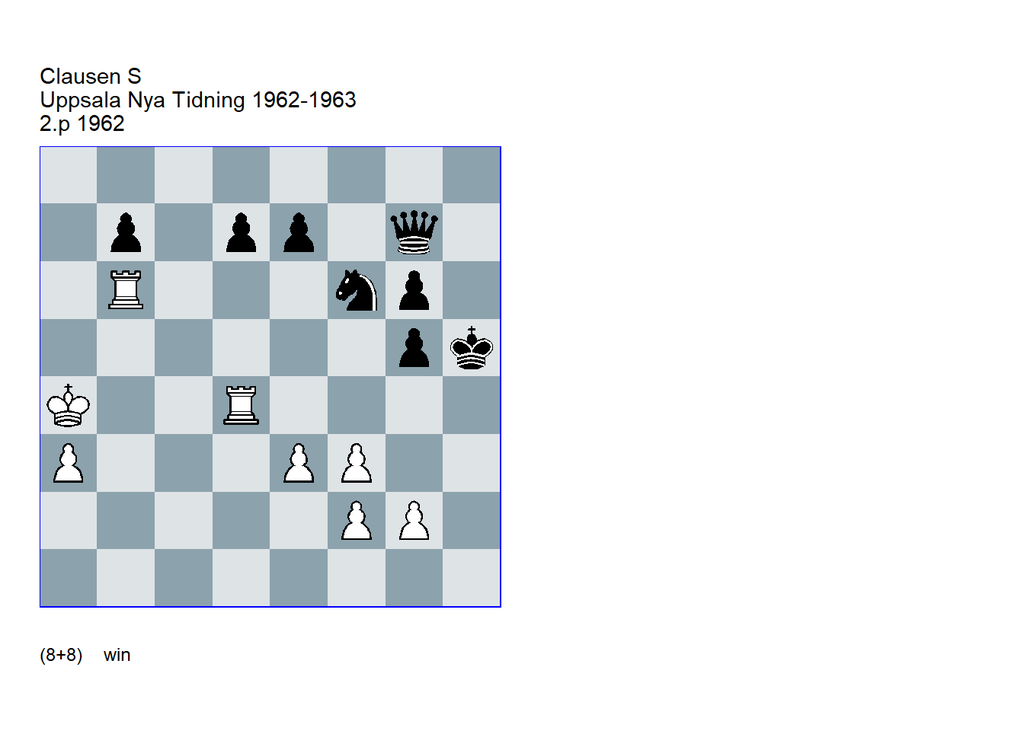

GBR: +3203.55a4h5 S FEN: 8/1p1pp1q1/1R3np1/6pk/K2R4/P3PP2/5PP1/8 w - - 0 1

(EG#00092); source: Uppsala Nya Tidning 1962; Ring ty: 11.pl Sweden Ch. 1963-1965; S: Neuenschwander=B beatochess no.17 10/2026 (web). **1. Rd1 g4** (1… Kh6 2. Rh1+ Nh5 3. Rxh5+ Kxh5 4. Rb1 g4 5. f4 g3 6. f3 g5 7. f5 g4 8. f4) **2. f4 g3 3. f3 g5 4. f5 Ng4! 5. fxg4+ Kxg4 6. Rf1 Kh5 7. Rh6+! Kg4 8. Rf4+ gxf4 9. Rg6+! Qxg6 10. fxg6** e.g. **10… f3 11. gxf3+!** ( or 11. g7) **11… Kxf3 12. g7 1-0**.

### 2.1.5 Dvizov +4100.36h8g5 (1976). Cook

**2. Kxg7** cooks the second modification.

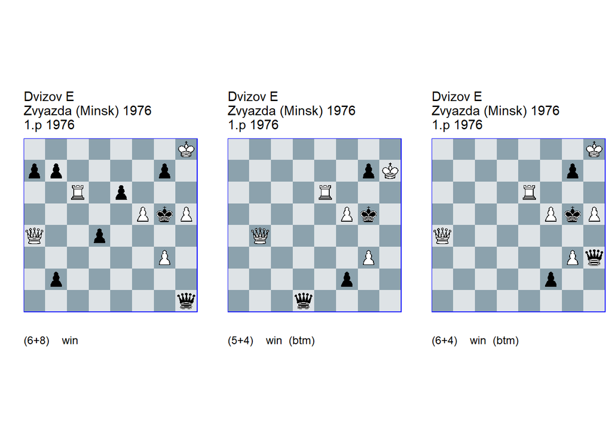

GBR: +4100.36h8g5 FEN: 7K/pp4p1/2R1p3/5PkP/Q2p4/6P1/1p6/7q w - - 0 1

(EG#04950); source: Zvyazda (Minsk) 1976; Ring ty: 2.pl 3rd Belarus Ch. 1977-1980 **1. Rxe6! Qxh5+ 2. Kg8! b1=Q 3. Qxd4 Qxf5 4. Rg6+! Qhxg6** (4… Qfxg6 main 5. Qf4#) (4… Kxg6 main 5. Qxg7#) **5. Qh4# 1-0**.

GBR: +4100.22h7g5 M FEN: 8/6pK/4R3/5Pk1/1Q6/6P1/5p2/3q4 b - - 0 1

source: Zvyazda (Minsk) 1976; (m): Pervakov=O (Shakhmatny Etyud kak Istkustvo-10 2023) **1… Qh5+!** (1… f1=Q 2. Qh4+ Kxf5 3. Qe4+ Kg5 4. Rg6+ Kh5 5. Qh4#) **2. Kg8! f1=Q 3. Qd4!** (3. Qd2+? Kg4!) (3. Qe7+? Kg4!) **3… Qxf5** (3… Qff3 4. Qxg7+ Kxf5 5. Re5#) **4. Rg6+! Kxg6** (4… Qfxg6 main 5. Qf4#) (4… Qhxg6 main 5. Qh4#) **5. Qxg7# 1-0**.

GBR: +4100.32h8g5 M U2 FEN: 7K/6p1/4R3/5PkP/Q7/6Pq/5p2/8 b - - 0 1

source: Zvyazda (Minsk) 1976; (m): Dvizov=E (Shakhm. i Shaskki BSSR no.9 5/ 1981); U2: Neuenschwander=B beatochess no.17 10/2026 (web). **1… Qxh5+ 2. Kg8!** (2. Kxg7! **cook** **BN** 2… f1=Q 3. g4) **2… f1=Q 3. Qd4! Qxf5** (3… g6 4. f6!) **4. Rg6+! Kxg6** (4… Qfxg6 main 5. Qf4#) (4… Qhxg6 main 5. Qh4#) **5. Qxg7# 1-0**.

### 2.1.6 Janosi =0044.11a2f6 (1975). Correction (VH)

Volker Hergert corrected the study.

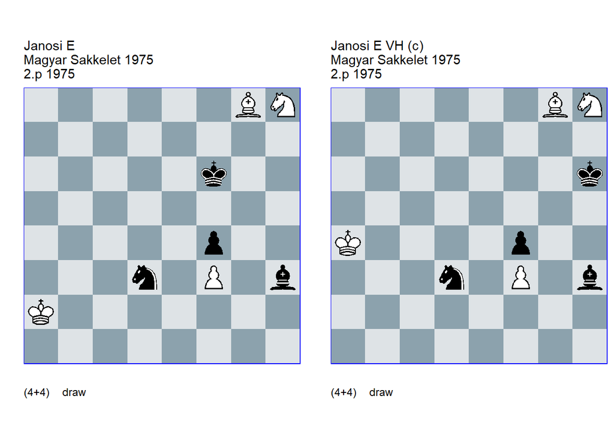

GBR: =0044.11a2f6 U3 FEN: 6BN/8/5k2/8/5p2/3n1P1b/K7/8 w - - 0 1

(EG#02863); source: Magyar Sakkelet#1138 6/1975; U3: Mikitovics=J source unknown 2008; Ring ty: 4.pl 15th Romanian Ch. 1975-1976( Revista Romana de Sah no. 1 1/1979) **1. Kb3!** (1. Bb3? Nc1+ 2. Kb2 Nxb3 3. Kxb3 Bg2) (1. Bc4? Ne5! 2. Kb3 Kg7) (1. Kb3) **1… Kg7** (1… Ne5 2. Kc3 Nxf3 (2… Kg7 3. Kd4 Nxf3+ 4. Ke4 Nd2+ 5. Kxf4 Kxg8 6. Ng6) 3. Bd5! (3. Nf7? Kg7) 3… Ne5 (3… Ng5! **cook** JM ) 4. Kd4) **2. Kc3 Ne1** (2… Bf5 3. Be6!) **3. Bc4!** (3. Bd5? Kxh8 4. Kd4 Kg7 5. Ke5 Ng2 6. Bc4 Kg6 7. Ba6 Kh5! 8. Bf1 Kg5! 9. Kd4 Kh4 10. Ke5 Kg3 11. Ke4 Bf5+ 12. Kxf5 Ne3+) **3… Kxh8 4. Be2 Kg7 5. Kd2 Ng2 6. Bf1 Kf6 7. Ke2 Ke5 8. Kf2 Kd4 9. Kg1!** (9. Bxg2? Bxg2 10. Kxg2 Ke3 11. Kg1 Kxf3) **9… Ke3 10. Kh2 Kf2 11. Bxg2 Bxg2** (11… Bc8 12. Bh1 Bb7 13. Bg2 Bxf3 14. Bh3) **1/2-1/2**.

GBR: =0044.11a4h6 C FEN: 6BN/8/7k/8/K4p2/3n1P1b/8/8 w - - 0 1

(EG#02863); source: Magyar Sakkelet#1138 6/1975; Ring ty: 4.pl 15th Romanian Ch. 1975-1976( Revista Romana de Sah no. 1 1/1979); correction: Hergert=V beatochess no.17 10/2026 (web). **1. Kb3!** (1. Nf7+? Kg7 2. Ng5 Bd7+) (1. Bd5? Ne5 2. Nf7+ Nxf7 3. Bxf7 Bg2 4. Bd5 Kg5 5. Kb3 Kh4 6. Kc3 Kg3) **1… Kg7 2. Kc3 Ne1 3. Bc4 Kxh8 4. Be2 Kg7 5. Kd2 Ng2 6. Bf1 Kf6 7. Ke2 Ke5 8. Kf2 Kd4 9. Kg1!** (9. Bxg2? Bxg2 10. Kxg2 Ke3 11. Kg1 Kxf3) **9… Ke3 10. Kh2 Kf2 11. Bxg2 Bxg2** (11… Bc8 12. Bh1 Bb7 13. Bg2 Bxf3 14. Bh3) **1/2-1/2**.

### 2.1.7 Nadareishvili =1040.15h2h4 (1968). De-cooked (VH)

Volker de-cooked the study.

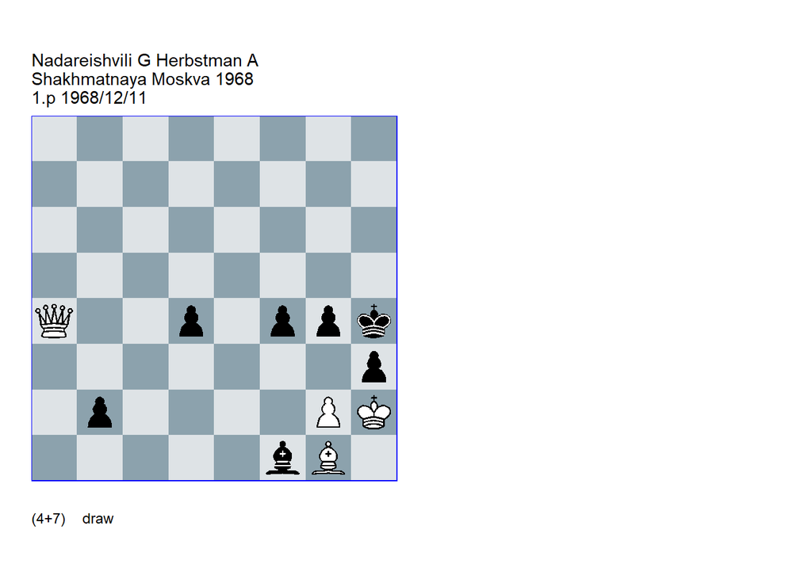

GBR: =1040.15h2h4 FEN: 8/8/8/8/Q2p1ppk/7p/1p4PK/5bB1 w - - 0 1

(EG#01216); source: Shakhmatnaya Moskva#66 no.27(265) 11-12-1968; U3: Keith=D HHdbIV 23-1-2007; de-cooked: Hergert=V beatochess no.17 10/2026 (web). **1. Bxd4!** (1. Bf2+? g3+ 2. Bxg3+ fxg3+ 3. Kg1 h2+ 4. Kh1 Bxg2+! 5. Kxg2 h1=Q+ 6. Kxh1 b1=Q+) **1… g3+** (1… b1=Q 2. Bf6+ Kh5 3. Qe8+ Kh6 4. Qf8+ Kg6 5. Qg7+ Kf5 6. Qh7+) **2. Kg1!** (2. Kh1? Bxg2+ 3. Kg1 b1=Q+) **2… h2+ 3. Kh1 Bxg2+! 4. Kxg2 f3+** (4… h1=Q+ 5. Kxh1 b1=Q+ 6. Kg2 Qe4+ 7. Kf1 Qh1+ 8. Ke2 f3+ 9. Ke3 ( 9. Kd2 ! no **cook** VH 9… Kh3 10. Qd7+! = ( or 10. Qb5! 10… Kh2 11. Qh5+!1) 10… Kg2) 9… Kh3 (9… f2! **cook** DK ) 10. Qd7+ Kg2 11. Qd5) **5. Kh1** (5. Kxf3? h1=Q+) **5… b1=Q+ 6. Bg1+ Qb4!** (6… Kh3 7. Qd7+) **7. Qxb4+ Kh3 8. Bxh2!** (8. Qh4+? Kxh4 9. Bxh2 gxh2! (9… f2? 10. Bxg3+ Kxg3) 10. Kxh2 Kg4) **8… f2 9. Qh4+! Kxh4 10. Bxg3+!** (10. Kg2? gxh2 11. Kxh2 f1=R!) (10. Bg1? f1=R) **10… Kxg3 1/2-1/2**.

### 2.1.8 Pogosyants +0013.12e7h5 (1964). Correction

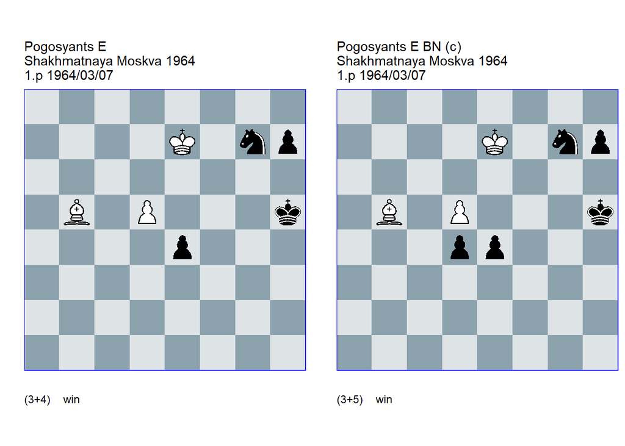

GBR: +0013.12e7h5 U2 FEN: 8/4K1np/8/1B1P3k/4p3/8/8/8 w - - 0 1

(EG#00117); source: Shakhmatnaya Moskva#08 no.5(147) 7-3-1964; U2: Van, der, Heijden=H HHdbVII 2-6-2024 **1. Kf6!** (1. d6? Nf5+) **1… Kh6 2. d6 Ne8+!** (2… e3 3. d7 e2 4. Bxe2 Ne8+ 5. Ke5 (5. dxe8=Q?) ) (2… Nh5+ 3. Ke5) **3. Bxe8 e3 4. d7!** (4. Bb5? e2! 5. Bxe2) **4… e2 5. d8=N!** (5. d8=Q? e1=Q) **5… e1=N!** (5… e1=Q main 6. Nf7+ Kh5 7. Ne5+! Kh4 (7… Kh6 8. Ng4#) 8. Nf3+ Kg3 9. Nxe1) **6. Nc6!** (6. Ne6? Ng2 7. Nd4 Ne3! 8. Bf7 Ng4+) **6… Ng2 7. Ne7!** (7. Ne5! **cook** HH 7… Ne3 8. Bf7!) **7… Ne3 8. Ng8# 1-0**.

GBR: +0013.13e7h5 C FEN: 8/4K1np/8/1B1P3k/3pp3/8/8/8 w - - 0 1

(EG#00117); source: Shakhmatnaya Moskva#08 no.5(147) 7-3-1964; correction: Neuenschwander=B beatochess no.17 10/2026 (web). **1. Kf6 Kh6 2. d6 Ne8+ 3. Bxe8 e3 4. d7** (4. Bb5 d3! 5. d7 (5. Bxd3 e2 6. Bxe2) 5… e2 6. d8=Q e1=Q =) **4… e2 5. d8=N! e1=N!** (5… e1=Q 6. Nf7+ Kh5 7. Ne5+) **6. Nc6 Ng2 7. Ne7** ( 7. Ne5? Ne3 8. Bf7 d3) **7… Ne3 8. Ng8# 1-0**.

# 3 Recent awards and publications

## 3.1 Awards

### 3.1.1 Gatti 10-AT (2026)

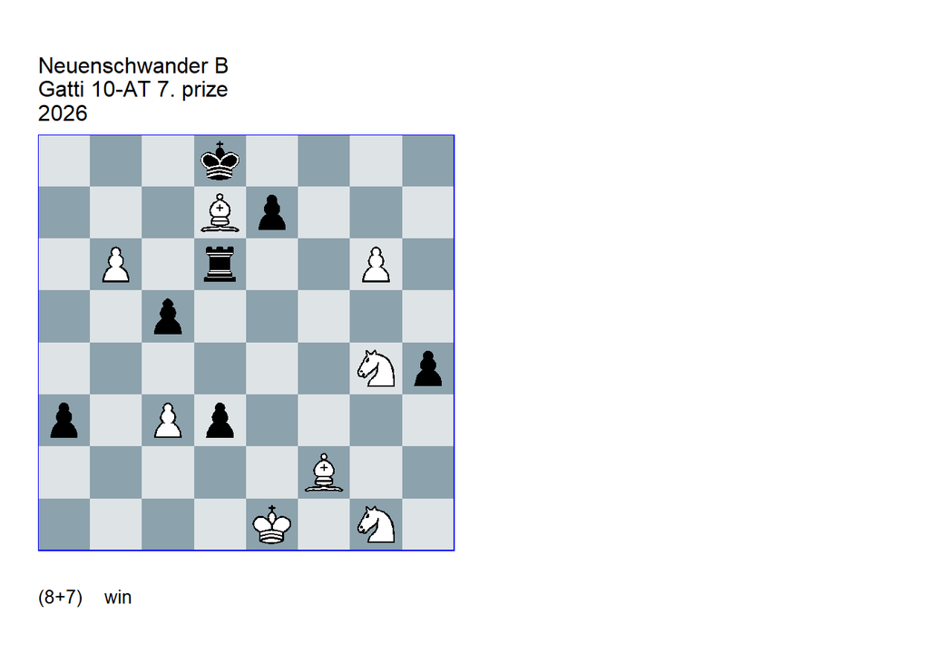

GBR: +0322.351e1d FEN: 3k4/3Bp3/1P1r2P1/2p5/6Np/p1Pp4/5B2/4K1N1 w - - 0 1

**1. g7** (1. b7? Kc7 2. Bxc5 a2 3. Bxd6+ exd6 4. g7 a1=Q+ 5. Kd2 Qb2+ 6. Kxd3 Qb1+ 7. Kd2 Qb2+ =) **1… Rg6 2. Be6!** (2. g8=Q+? Rxg8 3. Be6 Rxg4 4. Bxc5 (4. Ba2? Rg2 -/+) 4… Re4+ =) **2… Rxe6+ 3. Ne5! Rxe5+ 4. Be3! Rxe3+ 5. Ne2! Rxe2+ 6. Kf1 a2** (6… Kd7 7. g8=Q Kc6 8. Qd8 +-) **7. g8=Q+ Kd7 8. Qd5+ Ke8 9. Qa8+ Kf7 10. b7 1-0**.

Daniele Gatti:

> Watching this study unfold feels a bit like listening to a chess lesson between a father and his little daughter. *“Come on,” she says, eyes sparkling, “let’s sacrifice another piece!” The father hesitates. He looks at the board, at the King, at the growing danger. “Careful,” he replies. “We’re giving up a lot of material already. Let’s not exaggerate.” But the girl insists. And the board seems to agree with her. White begins innocently enough with 1.g7, pushing the pawn forward with confidence. Black resists, but after 2.Be6!, the sacrifices start to pile up. Each time the father frowns: “Are you sure? That’s another piece gone…” Rook after Rook is taken, Bishops step into fire, Knights jump in to be doomed. With 3.Ne5!, 4.Be3!, 5.Ne2!, White calmly offers everything. The white King, meanwhile, is becoming more and more uncomfortable. Space shrinks, flight squares disappear, and suddenly there is a serious threat of checkmate. Now the father finally loses his patience. “All right,” he says, “this is enough. You’ve sacrificed too much. Look at our position!” The girl smiles. “Don’t worry. Now watch.” With perfect timing, the pawn queens: 7.g8=Q+. The tension dissolves instantly. What looked like recklessness is revealed as careful planning. The newly born Queen takes over the board with just a few precise checks, and after 10. b7, the win is beyond doubt.* A charming and instructive study: a cascade of sacrifices that never lose control, guided by a clear final idea. What at first seems like childish enthusiasm, a memory of times when all was simpler, turns out to be deep calculation — and the father, in the end, can only nod in quiet admiration. Exactly as the judge does, every time he replays this study.

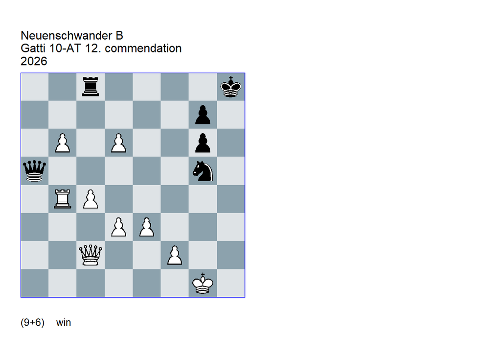

GBR: +4403.62b1h8 FEN: 2r4k/6p1/1P1P2p1/q5n1/1RP5/3PP3/2Q2P2/6K1 w - - 0 1

**1. b7** (1. d7? Rf8 =) (1. Rb1? Nf3+ 2. Kg2 Qh5 3. Rh1 Nh4+ 4. Kf1 g5 = 5. Qe2 Qf7 6. Qg4 Rf8 =) **1… Rb8** (1… Nf3+ 2. Kf1 Rb8 3. Qa4 +/-) **2. Rb1** ( 2. Qb2? Qf5! =) (2. Qb1? Nf3+ 3. Kg2 Qh5 4. c5 Rxb7! 5. Rxb7 (5. c6 Rxb4 6. Qxb4 Ng5 =) 5… Qg4+ 6. Kf1 Nd2+ 7. Ke1 Nxb1 8. d7 Qg1+ 9. Ke2 Qg4+ =) **2… Nf3+** (2… Qf5 3. f4 +/-) **3. Kg2** (3. Kf1? Nd2+ 4. Ke2 Nxb1 =) **3… Ne1+** (3… Nh4+ 4. Kh3 Qh5 5. Qd1! Nf3+ 6. Kg2 Qg4+ 7. Kf1 Nh2+ 8. Ke1 Nf3+ 9. Ke2 +/-) (3… Qh5 4. Qd1 +/-) **4. Rxe1 Qxe1 5. c5** (5. d7? Qb4 6. c5 Qg4+ 7. Kf1 Qxd7 8. c6 Qh3+ 9. Ke2 Rf8 =) (5. d4? Qb4 6. c5 (6. Qe4 Qxc4 7. d7 Qc7 8. Qe8+ Kh7 9. Qc8 Qd6 10. e4 g5 =) 6… Qxb7+ 7. c6 Qf7 8. c7 (8. Qe4 Rf8 9. Qf4 Kg8 10. Qxf7+ Kxf7 11. e4 (11. d5 Re8 =) 11… Ke6 12. e5 Kd5 13. c7 Ke6 =) 8… Rc8 9. Qe4 Kg8 10. Qf3 (10. d5 Re8 =) 10… Qd7 =) **5… Rxb7 6. d7!** (6. c6? Rb5 7. c7 Rg5+ 8. Kf3 Rf5+ 9. Kg2 Rg5+) **6… Rxd7** (6… Qa5 7. c6 Qg5+ (7… Rxd7 8. cxd7 Qd5+ 9. e4 Qxd7 10. Qd1 +/-) 8. Kf1 Ra7 9. Qb2! Kh7 10. Qd4 Ra8 11. c7 +/-) **7. Qa4!** Traps the rook! **7… Rxd3** ( 7… Rb7 main 8. Qa8+) (7… Rc7 main 8. Qh4+ Kg8 9. Qd8+) (7… Rd8 main ) (7… Rd5 main 8. Qa8+) (7… Re7 main 8. Qh4+) (7… Rf7 main 8. Qe8+) (7… Qc3 8. Qxd7 Qxc5 9. Qd8+ Kh7 10. Qh4+ Kg8 11. Qc4+) **8. Qh4+ Kg8 9. Qc4+ 1-0**.

Daniele Gatti:

> A study with natural play and a surprising rook domination in spite of his large mobility. The Author was inspired by a real game, citing his words: *“The study was inspired by the game Megan Paragua (12 years old!!) vs. Rose Atwell (16 years old!) of round 7 of the US Women’s Championship 2025, in which Megan was trying to trick Rose in a lost endgame. For more details, see the commentary by Katerina Nemcova, Yasser Seirawan, and Maurice Ashley on the YouTube video (starting at 3:15:10) of the Saint Louis Chess Club.”* The game-like configuration is well recognizable and very well adapted in study form.

### 3.1.2 Mario Garcia Memorial (2025-26)

See [Mario Marcio MT](https://www.problemistasajedrez.com.ar/preliminary-awards-torneo-memorial-mario-guido-garcia-uapa-2025-2026/) for the complete awards of the four sections.

Note that the first study (sec. A1), which was published online, was not included in the award.

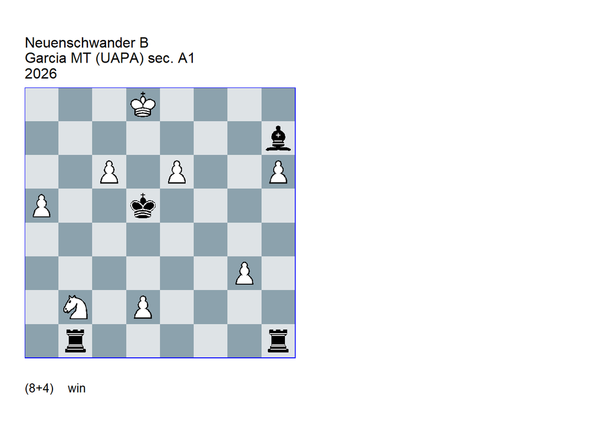

GBR: +0631.60d8d5 FEN: 3K4/7b/2P1P2P/P2k4/8/6P1/1N1P4/1r5r w - - 0 1

**1. c7!** (1. e7? Rbe1 2. c7 Bf5 -/+) **1… Rbc1** (1… Rhc1 2. e7) **2. e7 Rhe1** ( 2… Bg6 3. Nd3! Rxh6 4. Nf4+ Kd6 5. Nxg6) **3. Nd1! Rxc7** (3… Rxe7 main 4. Nc3+ Kd6 5. c8=Q! (5. c8=N+? Kc5 6. Kxe7 Rh1) ) **4. Ne3+ Kd6 5. e8=N+!** (5. e8=Q? Rec1 6. Qf8+ Ke6 7. Qe8+ Kd6 =) **1-0**.

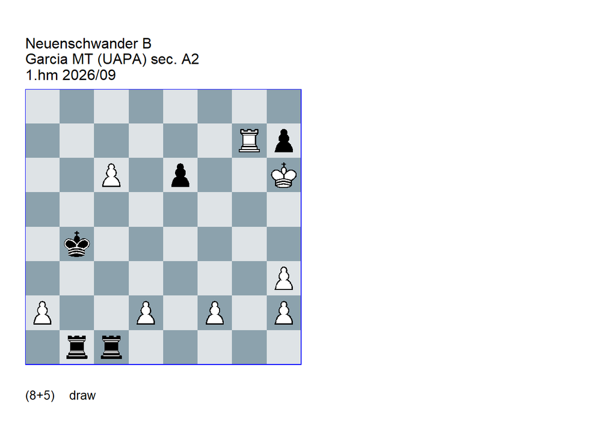

GBR: =0700.62h6b4 FEN: 8/6Rp/2P1p2K/8/1k6/7P/P2P1P1P/1rr5 w - - 0 1

Michal Hlinka:

> A fun demonstration of rook overloading, it would definitely be great in a problem solving competition.

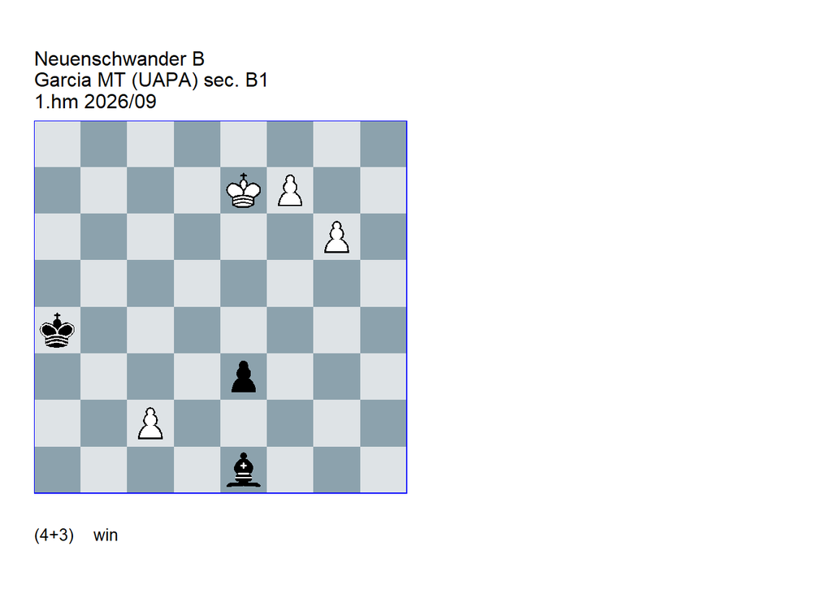

GBR: +0030.31e7a4 FEN: 8/4KP2/6P1/8/k7/4p3/2P5/4b3 w - - 0 1

**1. g7!** (1. Kd7? Bb4 2. g7 e2 3. g8=Q e1=Q = because Qe8 is not a check ) (1. Kd8? e2 2. f8=Q Ba5+ =) **1… e2 2. g8=Q** (2. f8=Q? Bb4+ 3. Kd7 Bxf8 4. gxf8=Q e1=Q =) **2… Bb4+ 3. Kd8!** (3. Kd7? e1=Q = because Qe8 is not a check ) (3. Kf6? Be7+! (3… e1=Q? 4. Qe8+ +-) 4. Kxe7 e1=Q+ leads to perpetual check, e.g. 5. Kf8 Qb4+ 6. Kg7 Qd4+ 7. Kh7 Qh4+ =) **3… Be7+** ( 3… e1=Q 4. Qe8+! +-) **4. Kd7! e1=Q 5. Qe8!** Pin and battery. **5… Qb4 6. Ke6+!** Forcing the black king to step on a bad square. (6. Qxe7? Qb7+ leads to perpeutal check, e.g. 7. Kd6 Qb4+ 8. Ke6 Qe4+ 9. Kf6 Qh4+ 10. Ke6 Qe4+ 11. Kd7 Qb7+ 12. Ke8 Qb8+ 13. Qd8 Qe5+ 14. Kf8 Qh8+ 15. Ke7 Qe5+ 16. Kd7 Qd5+) **6… Ka5** (6… Ka3 7. Qxe7 +-) **7. Qxe7 Qe4+ 8. Kd7** (8. Kf6 Qh4+ loss of time ) (8. Kd6 Qb4+ loss of time ) **8… Qb7+ 9. Ke8** (9. Kd8 Qb8+ loss of time ) **9… Qb8+ 10. Qd8+ 1-0**.

Eduard Eilazyan:

> There are several interesting moments in this study. After the black queen appears on the board, White creates a pin and a battery with a single move: 5.Qe8! Very impressive! The next move, 6.Ke6+!, creates the effect of foresight in the form of a preliminary action. The goal of this logical maneuver is to transfer the black king to the critical a5-square, which decides the outcome of the battle in White’s favor.

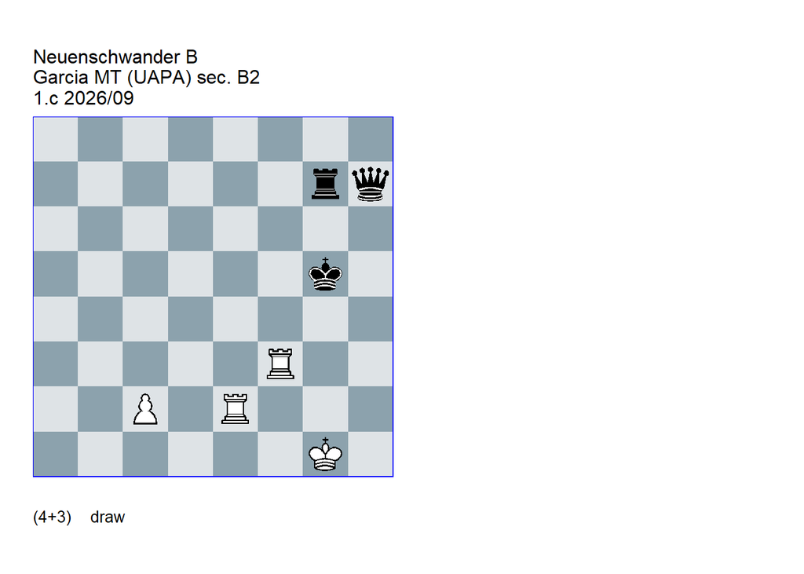

GBR: =3500.10g1g5 FEN: 8/6rq/8/6k1/8/5R2/2P1R3/6K1 w - - 0 1

**1. Rh2 Qg8** (1… Qe4 2. Rg3+ Kf6 3. Rf2+ =) **2. c3! Kg4** (2… Rg6 3. Rg2+ Kh4 4. Rf4+ Kh3 5. Rf3+ Kh4 6. Rf4+ Kh5 7. Rf5+ Kh6 8. Rf6 =) **3. Rf1!** ( Logical try: 3. Rff2? Kg3! reciprocal zugzwang 4. c4 Qa8 5. Rhg2+ Kh3 6. Rxg7 Qa1+ -+) (3. Rf6? Qd8! 4. Rg2+ Kh5 5. Rf5+ Kh6 -+) **3… Kg3** ( 3… Rg5 4. Rg2+ Kh3 5. Rf3+ Kh4 6. Rf4+ Kh5 7. Rf5 =) **4. Rff2!** reciprocal zuzwang (4. Rf5? Qa8 -+) (4. Rg2+ Kh4 5. Rf4+ Kh5 6. Rf5+ Kh6 7. Rf6+ Kh7 -+) **4… Kg4 5. Rf1 Kg3 6. Rff2** positional draw, …or **6… Qe6** Final trap **7. Rhg2+!** (7. Rfg2+? Kf3 8. Rxg7 Qe1#) **1/2-1/2**.

Daniele Gatti:

> A schematic construction, yet one that presents a clear and interesting thematic idea. The reciprocal zugzwang motif is handled with precision, and the alternation of roles between the sides is effectively demonstrated. While the execution follows a relatively familiar pattern, the study retains its appeal through clarity and logical consistency. The economy of means and the clean presentation of the central concept contribute positively to its overall impression.

### 3.1.3 Problem Paradise (2025)

Award: Problem Paradise 2025

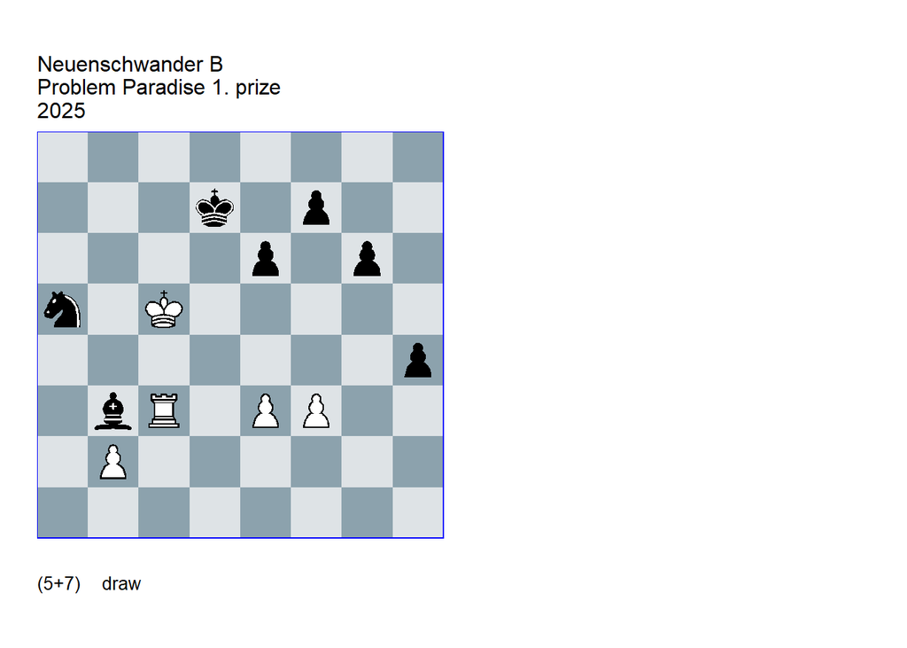

GBR: =0133.34c5d7 FEN: 8/3k1p2/4p1p1/n1K5/7p/1bR1PP2/1P6/8 w - - 0 1

**1. Kb4!** (1. Kb5? Ke7! 2. Kxa5 (2. Rc7+ Kd6 3. Rc1 Nc4) 2… Bd1) **1… Bd5** (1… Bc4 2. Kxa5 Bf1 (2… Be2 3. Rc2 Bxf3 4. Rf2 Bd5 5. Rxf7+ Kc6 6. Rh7 g5 7. Rh5) 3. Rb3! h3 (3… Kc7 4. Rc3+ Kd7 5. Rb3) (3… e5 4. Rb8 h3 5. Rh8) (3… Ke7 4. Rb8 Kf6 5. Rh8 h3 6. b4 Kg7 7. Rh4 g5 8. Rh5 Kg6 9. Rh8) 4. Rb8 e5 5. Rh8 g5 (5… Ke6 6. b4) 6. b4 e4 7. fxe4 g4 8. b5 Bg2 9. b6 Bxe4) (1… Ke7 2. Rc7+ Kf8 (2… Kf6 3. Kxa5) 3. Rc1!) **2. e4 Nc6+ 3. Kc5 Ba2 4. Ra3 Bb1 5. Ra1 Bc2 6. Rc1 Bb3 7. Rc3 Ba2** (7… Ba4 8. Ra3 leads to the **main** line ) ( 7… h3 8. Rxb3 h2 9. Rd3+ Kc7 10. Rd1 Ne5 11. Rh1) **8. Ra3 Bb1 9. Ra1 Bc2 10. Rc1 Ba4 11. Ra1** Now the carrousel turns in the other direction (11. b3 Bxb3 12. Rb1 Ba4 13. Ra1 h3 14. Rxa4 h2 15. Ra1 Ne5) (11. Rc4? Bd1) **11… Bb3 12. Ra3 Bc2 13. Rc3 Bb1 14. Rc1 Ba2 15. Ra1 Bb3 16. Ra3 1/2-1/2**.

Arpad Rusz:

> Perpetual pursuit of the bishop by a rook. What is new compared to the previous works? In this study, in addition to a new geometry, the chase can switch its sense of rotation from counter-clockwise to clockwise!

## 3.2 New publications

### 3.2.1 Die Schwalbe (2026)

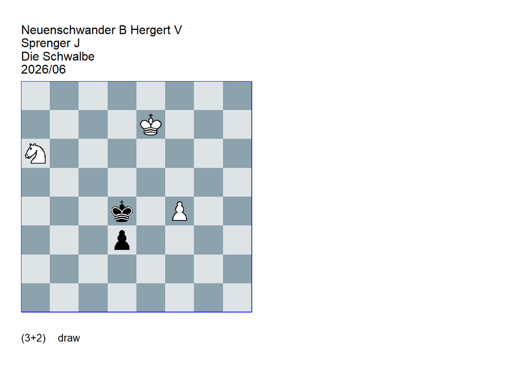

GBR: =0001.11e7d4 FEN: 8/4K3/N7/8/3k1P2/3p4/8/8 w - - 0 1

**1. Nc7!** ( Thematic try: 1. Nb4? d2 2. Nc2+ Ke4! (2… Kd3? 3. f5! d1=Q 4. f6 Qe2+ 5. Kf8 =) 3. Ne3 Kxe3 4. f5 d1=Q 5. f6 theme: pawn on f6 und Black to move. Here the black king is to close to the action 5… Kf4 6. f7 Qe2+ ( or 6… Qe1+) ) (1. f5? d2 2. f6 d1=Q 3. f7 Qe2+ ( or 3… Qe1+ ) ) (1. Nc5? Kxc5 2. f5 d2 3. f6 d1=Q 4. f7 Qd6+ 5. Ke8 Qe6+ 6. Kf8 Kd6) **1… d2 2. Nb5+ Kd3 3. Nc3! Kxc3 4. f5 d1=Q 5. f6 Qe2+ 6. Kf8** Black can do nothing against f7…. **1/2-1/2**.

### 3.2.2 EG (2026)

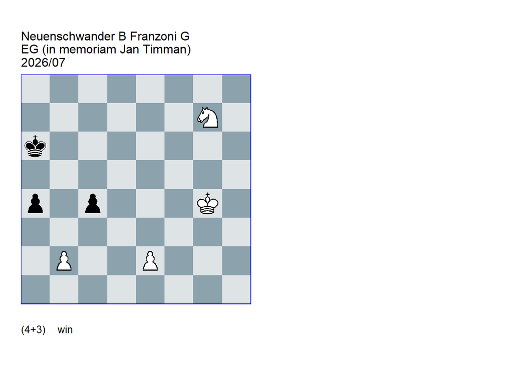

GBR: +0001.22g4a6 FEN: 8/6N1/k7/8/p1p3K1/8/1P2P3/8 w - - 0 1

**1. Ne6!** (1. Nf5? c3 2. bxc3 a3 3. Nd4 a2 4. Nc2 Kb5 5. e4 Kc4 6. e5 Kxc3 7. Na1 Kb2 =) **1… Kb5** (1… c3 2. Nc5+ Ka5 (2… Kb5 3. Nxa4 c2 4. Nc3+ Kc4 5. Na2 Kb3 6. Nc1+ Kxb2 7. Nd3+ +-) 3. Nxa4 c2 4. Nc5 c1=N 5. Kf3 +-) **2. Nd4+ Kb4** (2… Kc5 3. e3! (3. Nc2? c3 4. bxc3 Kc4 5. e4 Kxc3 6. Na3 Kb3 =) 3… c3 4. b3! c2 5. bxa4 c1=N 6. a5 Nd3 7. Nb3+ +-) **3. Kf3!** (3. Kf4? c3 4. bxc3+ Kc4! 5. Ke3 (5. Ke4 a3 6. Nc2 a2 =) 5… Kxc3 = reciprocal zugzwang ) (3. e4? c3 4. bxc3+ Kc4! (4… Kxc3 5. e5 Kxd4 6. e6 a3 7. e7 a2 8. e8=Q a1=Q 9. Qh8+ +-) 5. e5 a3 6. e6 a2 7. Nc2 Kxc3 8. Na1 Kb2 =) **3… c3 4. bxc3+ Kc4!** (4… Kxc3 5. Ke3 leads to the **main** line ) **5. Kf2!** (5. Ke3? Kxc3 = reciprocal zugzwang ) **5… Kxc3** (5… a3 6. Ke1 a2 7. Nc2 Kxc3 8. Kd1 +-) **6. Ke3** reciprocal zugzwang **6… Kc4** (6… a3 7. Nb5+ +-) **7. Nf5!!** (7. Nc2 Kc3 8. Nd4 loses time (8. Na3? Kb3 9. Nb5 Kb4! (9… Kc4? 10. Nd6+ Kb3 11. Kd2 a3 12. Nb5 a2 13. Nd4+ +-) 10. Nd4 Kc3 = reciprocal zugzwang ) ) **7… a3** (7… Kc3 8. Nd6 +-) **8. Kd2 a2 9. Ne3+ Kb3 10. Nc2 1-0**.

### 3.2.3 Polish Chess Federation (2026)

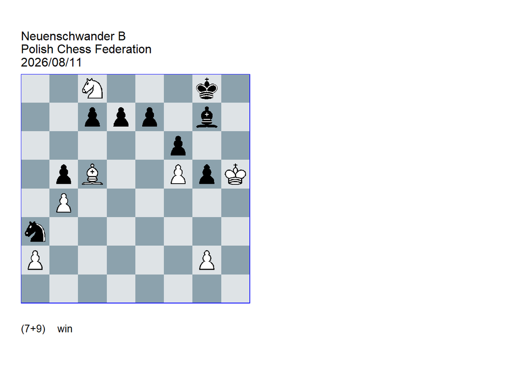

GBR: +0044.46h5g8 FEN: 2N3k1/2ppp1b1/5p2/1pB2PpK/1P6/n7/P5P1/8 w - - 0 1

**1. Kg6! e6** (1… e5 concedes the d5-square: 2. Ne7+ Kf8 3. Nd5+ d6 4. Ba7 c6 5. Nc7 Bh8 6. Kh7 d5 7. Ne6+ +-) **2. Ne7+ Kh8** (2… Kf8 3. fxe6 dxe6 4. Nf5+ +-) **3. Kf7!** ( After 3. fxe6? dxe6 Black’s counterplay is jsut sufficient. e.g., 4. Kf7 f5 5. Kxe6 f4 6. Kf5 Nc2 7. Kxg5 Bc3 8. Nc6 Bd2 9. Kf5 Ne1 10. Ke4 Nxg2 11. Kf3 Ne3 12. Kxf4 Nc2+ 13. Ke4 Be1 14. Kd5 Kg7 15. Ke6 Bc3 16. Kd7 Kf7 17. Kxc7 Ke6 18. Kb6 Kd5 19. Kxb5 Na3+ 20. Kb6 Nc4+ 21. Kc7 Na3 =) **3… Nc4** (3… Nb1 4. Bd4! e5 5. Bf2 Nc3 6. Be1 Ne4 7. Ke8 the White advantage on the queen side is decisive, e.g. 7… c5 8. Kxd7 c4 9. Nd5 +-) **4. Ke8!** (4. fxe6? Ne5+ 5. Ke8 dxe6 =) **4… Ne5** (4… exf5 5. Kxd7 f4 6. Kc6 +-) **5. Ng6+** (5. Kd8? exf5 6. Kxc7 Bf8 7. Nxf5 Bxc5 8. bxc5 Kg8 =) **5… Nxg6 6. fxg6 d6** (6… Kg8 7. Kxd7 e5 8. Kc6 e4 9. Kxb5 f5 10. a4 +-) **7. Bxd6!!** A suprising sacrifice. **7… cxd6** (7… Kg8 8. Bxc7 e5 (8… f5 9. Kd7 e5 10. Kc6 e4 11. Kxb5 f4 12. Kc4 +-) 9. Kd7 Bf8 10. a3 e4 11. Kc6 f5 12. Kxb5 f4 13. Kc4) **8. Kf7!** The last of White’s powerful king moves… Now Black can do nothing against White’s pawns on the queen side ( Not 8. a4?? Kg8 -+) **8… d5 9. a4 bxa4 10. b5 a3 11. b6 a2 12. b7 a1=Q 13. b8=Q+ 1-0**.

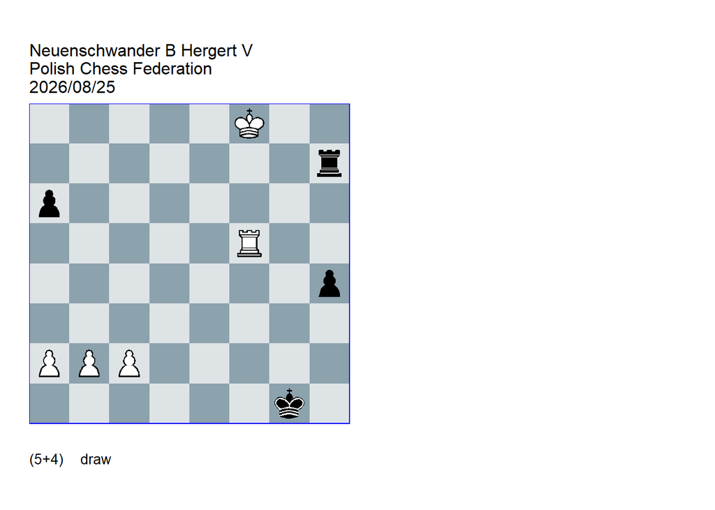

GBR: =0400.32f8g1 FEN: 5K2/7r/p7/5R2/7p/8/PPP5/6k1 w - - 0 1

Black threatens 1…h3. **1. Kg8** (1. c4? h3 -+) **1… Re7** ( After 1… Rh6 2. Kg7 Re6 3. Kf7 Re4 4. Ra5 White’s king position is improved compared to the **main** line (on f7 instead of f8). After 4… h3 5. Rxa6 h2 6. Rh6 h1=Q 7. Rxh1+ Kxh1 and White would therefore be for choice how to achieve a draw (8.c4, 8.b3, 8.c3). ) (1… Rc7 2. Rh5 Rxc2 3. Rxh4!1) **2. Kf8!** (2. Rh5? Re4 3. Kf7 Kg2 4. Kf6 h3 -+) **2… Re4** (2… Re2 3. Rh5!1) **3. Ra5!** (3. Rf6? a5! -+) (3. Rh5? Kg2 4. Kf7 h3 -+) **3… h3 4. Rxa6 h2 5. Rh6 h1=Q** (5… Kg2 6. c4! Kg3 7. Rxh2 Kxh2 8. c5 =) **6. Rxh1+ Kxh1 7. c4!** Activating the king is worth a pawn. ( Too slow is 7. b3? e.g. 7… Kg2 8. c4 Kf3 -+) **7… Rxc4** (7… Kg2 8. c5 Kf3 9. b4! Ke3 (9… Rxb4 10. Ke7 Rc4 11. Kd6!1) 10. b5 Kd4 11. c6 Kd5 12. c7 Rc4 13. b6 Kd6 14. Ke8!1) **8. Ke7 Rd4** (8… Rc2 9. b4 Rxa2 10. Kd6 Rb2 11. Kc5!1) (8… Kg2 9. Kd6 Kf3 10. b3 Rh4 (10… Rc3 11. b4 =) 11. a4 Ke4 12. a5 Kd4 13. Kc6 Rh6+ 14. Kb5 Kd5 15. a6 =) (8… Rb4 9. b3!1) **9. a3 Kg2 10. b4 Kf3 11. b5 Ke4 12. b6 Rd3 13. a4 Kd5 14. Kd7 Kc5+ 15. Kc7 Rh3 16. b7 Rh7+ 17. Kc8 Kc6 18. b8=N+ 1/2-1/2**.

### 3.2.4 Problem Paradise (2026)

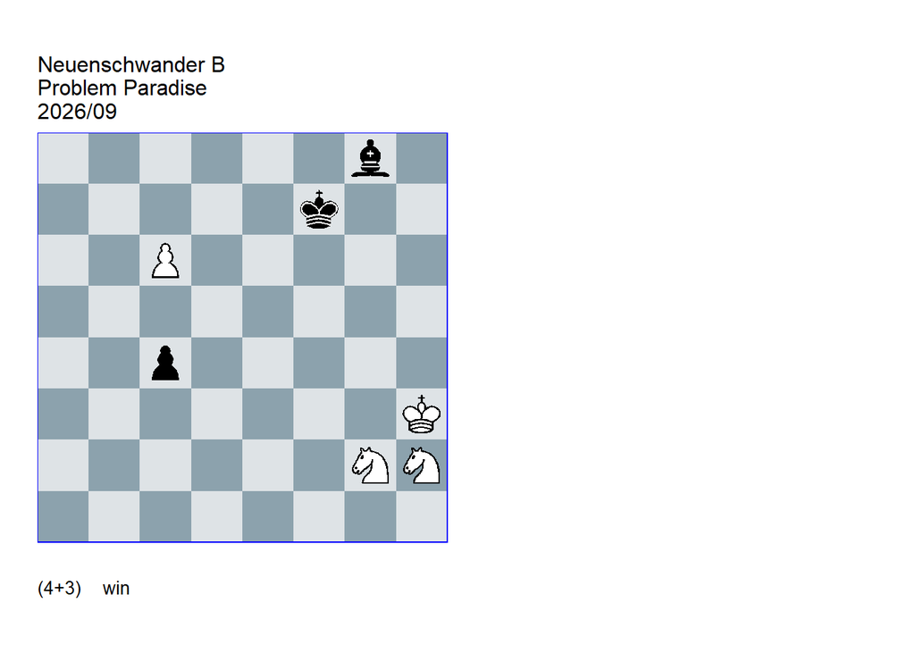

GBR: +0032.11h3f7 FEN: 6b1/5k2/2P5/8/2p5/7K/6NN/8 w - - 0 1

**1. c7 Ke7** In the sequel Black must play actively because three knights win against one bishop. (1… Kf6? 2. Ng4+ +-) **2. c8=N+!** (2. c8=Q? Be6+ 3. Qxe6+ Kxe6 = because Black’s pawn is advanced too far ) **2… Kd7** In the sequel Black must play actively because three knights win against one bishop. **3. Nb6+ Kc6 4. Na4 Kb5 5. Nc3+ Kb4 6. Ne2 c3** Mobilizing the passed pawn is Black’s best resource. **7. Ne3!** (7. Ne1? Bc4! 8. Nf4 (8. Nc1 c2 =) (8. Nd4 Kc5 9. Nhf3 Bd5 =) 8… Kb3 9. Nhf3 c2 10. Nd4+ Kc3 11. Ndxc2 Kd2 12. Kg3 Bb3 =) **7… Bc4 8. Nf4 Kb3** (8… Bb3 9. Nd3+ Ka3 10. Nf3 +-) **9. Nf3 c2 10. Nd2+ Kc3** (10… Kb4 11. Ndxc4 c1=Q 12. Nd3+ +-) (10… Ka2 11. Nxc2 +-) **11. Ndxc4 c1=N** 11… c1=Q 12. Ne2+ loses the queen. The underpromotion is the best defence, but it is insufficient: three knights against one knight is a theoretical win. The miniature shows a three-knigths-vs-one bishop ending transitioning into a three-knigths-vs-one-knight ending. **1-0**.

### 3.2.5 SCHACH (2026)

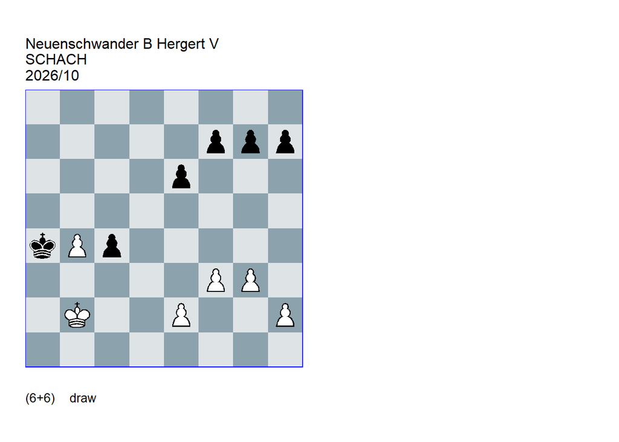

GBR: =0000.55c2a4 FEN: 8/5ppp/4p3/8/kPp5/5PP1/1K2P2P/8 w - - 0 1

**1. Kc3 Kb5** The stillstand on the queenside determines further play, which requires unique moves from both sides. **2. h4!** (2. e4? f5! 3. e5 (3. g4 f4 -+) 3… g5! -+) (2. g4? g5 3. e3 e5 -+) **2… f5!** The threat g3-g4 must be prevented. (2… g6? 3. g4! +-) (2… e5? 3. g4! +-) (2… f6? 3. h5! +-) **3. h5!** (3. g4? f4! -+) **3… e5 4. h6!** (4. g4? fxg4 5. fxg4 e4 6. g5 e3 7. g6 h6 -+) **4… g5** (4… gxh6 5. e4 fxe4 6. f4! (6. fxe4? h5 -+) 6… exf4 7. gxf4 e3 8. f5 e2 9. Kd2 Kxb4 10. f6 c3+ 11. Kxe2!1) **5. e3** (5. g4? f4 -+) **5… f4 6. gxf4** (6. exf4? gxf4 7. g4 e4 8. g5 exf3 9. g6 f2 -+) **6… exf4 7. e4 g4 8. e5 Kc6** (8… g3 9. e6 Kc6 10. b5+ Kd6 11. b6 Kxe6 12. b7!1) (8… gxf3 9. e6 f2 10. e7 f1=Q 11. e8=Q+!1) **9. Kxc4 g3 10. b5+ Kd7 11. b6 g2 12. e6+! Kxe6 13. b7 g1=Q 14. b8=Q Qf1+ 15. Kd4** ( oder 15. Kc5 Qf2+ 16. Kc4 as in the **main** line ) (15. Kc3? Qxf3+ -+) **15… Qf2+ 16. Kc4 Qc2+ 17. Kd4 Qd2+ 18. Kc4 Qd5+ 19. Kb4** (19. Kc3? Qxf3+ -+ ) **19… Qd4+ 20. Kb3!1 1/2-1/2**.

### 3.2.6 Sinfonie Scacchistiche (2026)

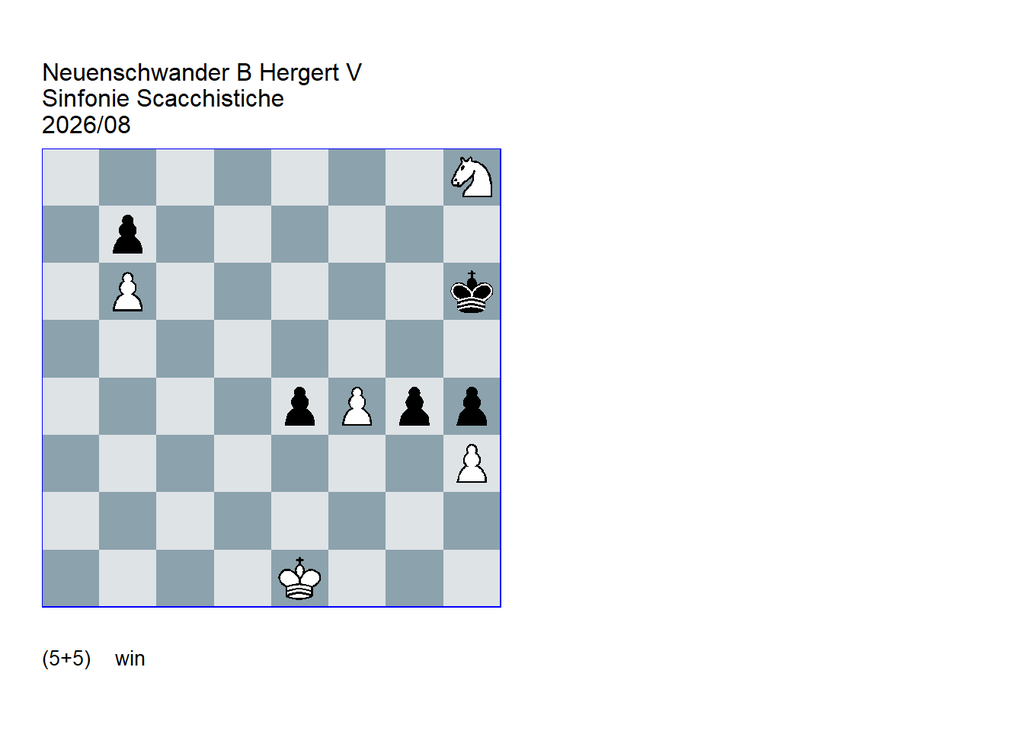

GBR: +0001.34e1h6 FEN: 7N/1p6/1P5k/8/4pPpp/7P/8/4K3 w - - 0 1

**1. Nf7+ Kh5 2. Ng5!** (2. Nd6? e3! 3. hxg4+ (3. Ne4 gxh3 4. Nf6+ Kg6 5. Ng4 Kf5) 3… Kxg4 4. Ke2 Kxf4 5. Nxb7 h3 =) **2… gxh3 3. Nxe4 h2** (3… Kg4 4. Kf2) **4. Nf2 h1=Q+** Black’s only way for active counterplay **5. Nxh1 Kg4 6. Nf2+ Kxf4 7. Nd3+ Ke4 8. Nb4!** (8. Nc5+? Kd5 9. Nxb7 Kc6) **8… Kd4 9. Na6 Kd5 10. Nc7+ Kc6 11. Na8!** This concludes the corner-to-corner-to-corner journey of the white knight. **1-0**.

### 3.2.7 Tehtavaniekka (2026)

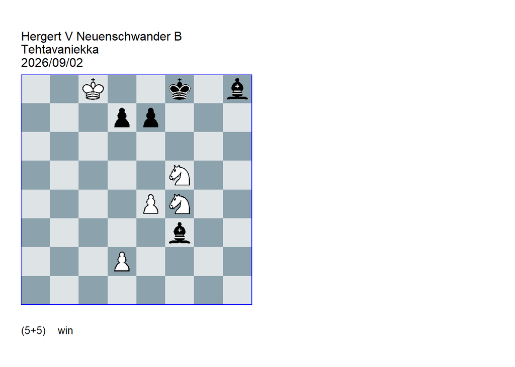

GBR: +0062.22c8f8 FEN: 2K2k1b/3pp3/8/5N2/4PN2/5b2/3P4/8 w - - 0 1

**1. Ng6+ Kg8 2. e5 Bg4 3. Ne3!** (3. Nfxe7+? Kf7 4. Kd8 (4. Nxh8+ Kxe7 =) 4… Bg7 =) (3. Nh6+? Kg7 4. Nxg4 Kxg6 =) **3… Bh3!** (3… Be6 4. Nxh8 Kxh8 (4… d6+ 5. Kd8 +-) 5. Kd8 Kg7 (5… d6 6. Kxe7 +-) 6. Kxe7 +-) (3… Bh5 4. Nxh8 +-) **4. Nf4!** switchback (4. Kd8? Bg7 =) (4. Nxh8 d6+ 5. Kd8 Kxh8 6. Kxe7 (6. exd6 exd6 =) 6… dxe5 =) **4… Be6** the only square for the bishop (4… Bxe5 5. Nxh3 +-) **5. Nxe6 dxe6 6. Nc4!** (6. d4? Kf7 7. Kd7 Bg7 8. Ng4 (8. Ng2 Bh6 =) 8… Bf8 =) (6. Kd7? Bxe5 =) **6… Kf8** (6… Bg7 7. d3! Kf8 8. Kd8! leads to the mainline ) **7. Kd8!** (7. Kd7? Bg7! 8. Kxe6 Ke8 9. d3 Bh6! =) (7. d4? Bg7 8. Kd7 Bh6 9. Kxe6 Ke8 =) **7… Bg7 8. d3!** (8. Kd7? Bh6 = see above ) **8… Kf7** (8… Bh6 9. Na5! Bf4 10. Nc6 Kf7 11. Kd7! Bg5 12. Nd8+ +-) **9. Kd7 Bh8** (9… Bh6 10. Na5! +-) (9… Bf8 10. Na5! +-) **10. d4 Bg7 11. Nd6+!** (11. Na5? Bh6 12. Nc6 Be3! 13. Nd8+ Kg6 14. Nxe6 (14. Kxe6 Bxd4 =) 14… Kf5 15. Kxe7 Bxd4 16. Nxd4+ Kxe5 =) **11… exd6** (11… Kg6 12. Kxe7 +-) **12. d5!** Irrespective of how Black continues, White will promote to a queen on e8 **1-0**.

### 3.2.8 The Problemist (2026)

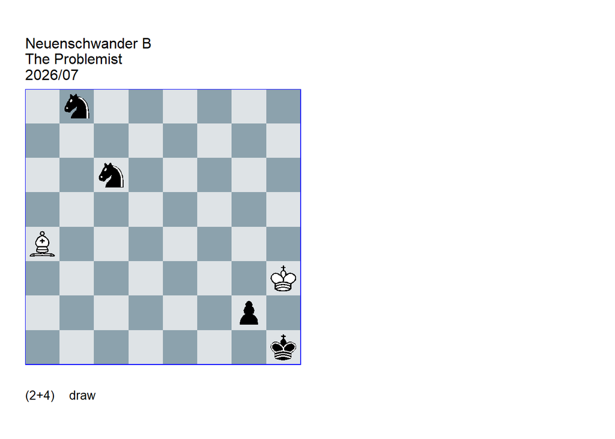

GBR: =0016.01h3h1 FEN: 1n6/8/2n5/8/B7/7K/6p1/7k w - - 0 1

**1. Bb3!** (1. Bc2? g1=N+ 2. Kg3 Ne2+ 3. Kf2 Nc3 -+) (1. Bd1? Nd4 -+) **1… Ne7** (1… g1=N+ 2. Kg3 Ne2+ (2… Ne7 3. Bd1! leeads to the **main** line ) 3. Kf2 Nc3 4. Ke3 = e.g. 4… Ne7 (4… Na6 5. Kd3) (4… Kh2 5. Kd3 = Nb5 6. Ba4 Ne5+ 7. Ke4 =) 5. Kd4 Nb5+ 6. Kc5 =) **2. Bd1** (2. Bc2 g1=N+ 3. Kg3 Ne2+ -+) **2… g1=N+** Three knights win against one bishop, so White must exchange the bishop against one of the knights. **3. Kg3 Nf5+ 4. Kf4 Nd6 5. Ke5 Nb5 6. Ba4!** (6. Bc2? Nd7+ 7. Kd5 Nf6+ 8. Kc5 Nc3 -+) **6… Nc3 7. Be8!** Threatens Kd4 followed by Bb5, which isolates the black knight on b8. Now the **main** line splits according to how the threat is countered: **7… Nf3+** (7… Nge2 main 8. Bh5! Ng3 9. Kd4! Nb1 10. Be8 Nd2 11. Bb5 = and the knight on b8 is trapped. ) (7… Na6 main 8. Kd4! Nce2+ 9. Kc4 Nf4 10. Bf7 Nb8 11. Be8 Na6 12. Bf7 posiional draw ) **8. Kd6** Threatens Bc6. **8… Kg1** (8… Nd4 9. Kc7 Na6+ 10. Kb6 Nb4 11. Kc5 =) **9. Bc6 Nd4** (9… Nd2 10. Bb7! =) **10. Be4!!** Reaching the d3 square is key. (10. Bb7? Ndb5+ 11. Kc5 Kf2 -+) **10… Ndb5+** (10… Kf2 11. Kc7 Na6+ 12. Kb6 Nb4 13. Kc5 =) (10… Ncb5+ 11. Kd5 Na6 12. Bd3 =) (10… Nb3 11. Bd3 =) (10… Na6 11. Bd3 Nb4 12. Kc5 =) **11. Kc5 Kf2** (11… Nd7+ 12. Kb4 =) **12. Bd3 Nd7+** (12… Na6+ 13. Kb6) **13. Kb4 1/2-1/2**.

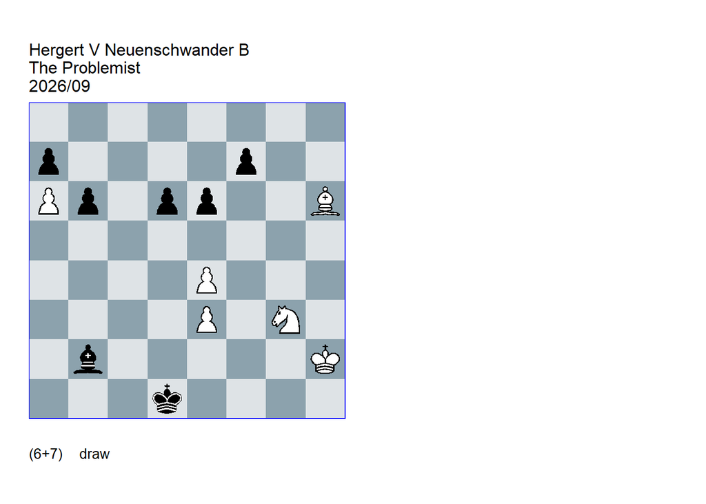

GBR: =0041.35h2d1 FEN: 8/p4p2/Pp1pp2B/8/4P3/4P1N1/1b5K/3k4 w - - 0 1

**1. Bg5!** It is crucial to threaten 2.Bd8 and 3.Bxb6 to provoke the f-pawn’s advance, which weakens the pawn on e6. (1. e5? Bxe5 -+) (1. Bf4? Be5 2. Bxe5 dxe5 3. Nh5 b5 -+ no Ng7xe6 ) (1. Bf8? Be5 -+) **1… f6** (1… Be5?? 2. Bd8! b5 3. Ba5! +-) **2. Bf4 Ba3** (2… Be5 leads to the **main** line ) ( 2… e5 3. Bh6 b5 4. Nf5!1) **3. Bh6!** (3. Nh5? b5 4. Nxf6 e5 5. Bg3 b4 -+) **3… Bb2 4. Bf4 Be5 5. Bxe5** (5. Nh5? b5 6. Nxf6 b4! -+) **5… dxe5** ( Stronger than 5… fxe5 after which White has different ways to draw, e.g., 6. Nf5) **6. Nh5 b5 7. Ng7!** First thematic try: (7. Nxf6? b4 8. Nd5 b3! 9. Nc3+ Kc1! 10. Nb5 b2 11. Na3 b1=Q 12. Nxb1 Kxb1 -+ In comparison to the **main** line, White cannot draw with 13.Kh1 (opposition) because the black king has time to capture the a6 pawn. ) **7… b4 8. Nxe6** In contrast to the 7.Nxf6 line, Black pawn structure (f6/e5 instead of e6/e5) gives White’s king access to the square f5, making Black’s plan to attack the a6 pawn too slow. **8… b3 9. Nc7!** Second thematic try: (9. Nc5? b2 10. Na4 Kc1 11. Nxb2 Kxb2 -+ White managed to eliminate the passed pawn, but loses the opposition. ) **9… b2 10. Nb5 Kc1** (10… b1=Q 11. Nc3+ Kc1 12. Nxb1 Kxb1 leads to the **main** line ) **11. Na3 b1=Q 12. Nxb1 Kxb1 13. Kh1!** Now it is Black to move! **13… Kc1 14. Kg1 Kd1 15. Kf1 Kc2 16. Kg2!** (16. Ke2? Kc3 -+ White loses the opposition. ) **16… Kd2 17. Kf2 Kc3 18. Kg3 Kd3 19. Kf3 Kc4 20. Kg4 Kb5 21. Kf5 Kxa6 22. Kxf6 Kb6 23. Kxe5!1 1/2-1/2**.